# Analysis of the ‘green’ state of Uzbekistan using Panel Data analysis

Muhammadibrohimov Botirjon

2024-03-11

## **Analysis of the green state of Uzbekistan using Panel Data analysis and VAR**

# Abstract

This research analyzes the state of the ‘green’ economy in Uzbekistan, focusing on the descriptive analysis of the situation within the last 20-30 years. The core element of the research is the analysis of the model: Random Effects model (Panel Data analysis). Due to certain statistical limitations of the data, the final conclusion of the research focuses on the ways to improve the statistics base of the Uzbekistan for further research purposes. In the case of the VAR model, the researcher attempts to forecast the amount of GHG emission (total) in the scenario if the actions and necessary policies are not taken and potential ESG risks this scenario might bring for economy, society and environment of Uzbekistan.

# Introduction

The world is facing unprecedented challenges in the 21st century, such as climate change, biodiversity loss, resource depletion, social inequality, and global pandemics. These challenges pose serious threats to the well-being of humanity and the planet, and require urgent and coordinated actions from all stakeholders. However, the current economic system, based on the capitalist model of production and consumption, is not capable of addressing these challenges effectively. On the contrary, capitalism is one of the main causes of these problems, as it relies on the exploitation of natural and human resources, the accumulation of wealth and power by a few, and the generation of externalities and waste that harm the environment and society. According to the United Nations Environmental Program (UNEP), today the richest 80 people own the same wealth as the 3.5 billion poorest people [1] (UNEP, 2015,p.16).

**Relevance of the topic.** According to the World Bank, Uzbekistan is one of the most energy- and carbon-intensive economies in the world, with a high dependence on fossil fuels, especially natural gas (World Bank Group, 2022, p. 10) [2] . This makes Uzbekistan vulnerable to external shocks, such as fluctuations in energy prices and trade policies, as well as to the impacts of climate change, such as water scarcity, desertification, and extreme weather events. Moreover, Uzbekistan faces significant challenges in terms of social development, such as poverty, unemployment, gender inequality, and low human capital [3].

> Therefore, there is a need for Uzbekistan to transition to a green economy and green growth, which are defined by the United Nations as “a system that results in improved human well-being and social equity, while significantly reducing environmental risks and ecological scarcities” [4]. A green economy and green growth can offer Uzbekistan multiple benefits, such as enhancing its economic competitiveness, diversifying its energy sources, increasing its resource efficiency, improving its environmental quality, and, last but not the least, achieving its balanced and inclusive development.

**The goal of the research** is to find the proven ways on the basis of econometric analysis and policies adopting which Uzbekistan’s green transition will flow fast and effectively, at the same time solving the main economic, social and environmental issues, and maintaining the green growth further.

**The object of the research** is the environment and economic system of Uzbekistan, and its transition to a green economy and green growth.

**Methodology**

The methodology of the research is based on the use of complex econometric models: Random Effects model (Panel Data analysis). These are statistical and econometric tools that allow to examine the relationships and trends among various economic and environmental variables, and to forecast their future values and scenarios. The research will use secondary data from various sources, such as the Eurostat, the OECD, the United Nations, and the Uzbekistan National Statistics Committee. The research will apply these methods and data to answer the following research questions:

- What are the main factors and drivers that influence Uzbekistan’s transition to a green economy and green growth?
- What are the main benefits and impacts of Uzbekistan’s transition to a green economy and green growth on its economic, social, and environmental performance and indicators?
- What are the best practices and policies that can facilitate and accelerate Uzbekistan’s transition to a green economy and green growth, and that can ensure its sustainability and inclusiveness?

**The tasks of the research are:**

- To provide the theoretical framework for Random Effects model (Panel Data analysis);
- To collect and analyze the data and information on the current state and trends of Uzbekistan’s economic and environmental performance and indicators, and to identify the gaps and opportunities for improvement;
- To apply the econometric methods to estimate and forecast the relationships and scenarios of various economic and environmental variables;
- To synthesize and interpret the findings and results of the data analysis, and to draw conclusions and implications of the research;
- To propose and suggest the best practices and policies that can facilitate and accelerate Uzbekistan’s green transition, and that can ensure its sustainability and inclusiveness.

# Literature Review

The concept and practice of green economy and green growth have emerged from various streams of thought and practice in the fields of economics, ecology, ethics, and politics. Some of the earliest critiques of the conventional economic system and its negative impacts on the environment and society can be traced back to the ancient Greek philosophers, such as Aristotle, who distinguished between oikonomia (The word “oikonomia” in Greek is written as οἰκονομία. It is derived from ancient Greek, where “οἶκος” (oikos) means “house” and “νόμος” (nomos) means “law” or “custom”) and chrematistics (“Chrematistics” is a term that also originates from Greek, specifically from the word “χρηματιστική” (chrematistikē). It is derived from “χρῆμα” (chrēma), meaning “money” or “wealth”)[ Aristotle used this term in his economic thought, and it refers specifically to the art of wealth acquisition and the study of wealth exchange. In contrast to oikonomia, which is concerned with the management of household and the efficient use of resources, chrematistics is more focused on the accumulation and use of wealth, particularly in the context of commerce and trade. Aristotle drew a distinction between the two, viewing oikonomia as a necessary and noble practice for the sustenance and well-being of the household and the state, whereas chrematistics was often seen in a more negative light, as it could involve the accumulation of wealth for its own sake.], and advocated for the former as the proper way of economic life, which respects the balance and harmony of the whole (Aristotle, 2009) [5]. This distinction can be seen as a precursor of green economy, as it emphasizes the importance of social and ecological values over monetary and materialistic ones, or, as described by the Aristotle himself, ““The function of the former is to provide and that of the latter to use”. Another ancient Greek contribution to the normative basis of green economy is the concept of virtue ethics, developed by Plato and Aristotle, which focuses on the moral character and actions of individuals, rather than on the consequences or rules of their behavior. Among the virtues, ecological virtue can be considered as the demonstration and practice of respect and care for the natural environment, which is essential for the well-being of human beings and other living beings (Plato and Aristotle, 2014). The opposite of ecological virtue is ecological vice, which is the manifestation and performance of disregard and harm for the natural environment, which leads to a lack of virtue and a less fulfilling existence. Plato and Aristotle’s virtue ethics imply that behaving in an environmentally responsible way is not only beneficial, but also moral and desirable [6].

The increasing trend of annual CO2 emissions in Uzbekistan, as recorded by both Uzhydromet and OECD, shows slight fluctuations above 95 million tonnes but remains below 125 million tonnes from 1990 to 2020. This trend experienced a surge in the early 2000s, followed by a decline between 2012 and 2016, and then resumed an upward trajectory post-2016, with a notable decrease in 2020. Notably, in 2021, the CO2 emissions per capita in Uzbekistan, indicating the average citizen’s contribution to total emissions, was recorded at 3.6 tonnes, significantly lower than the Central Asia average of 6.7 tonnes per person (OWD, 2023) [7]. Despite the rise in emissions, Uzbekistan’s contribution to global carbon emissions remains minor. In 2020, its emissions were 20 times less than the Eastern Europe, Caucasus, and Central Asia (EECCA) average, accounting for 5% of the region’s emissions. Over the last three decades, Uzbekistan’s share of global emissions has consistently been 0.33% (OWD, 2023), with the energy sector being the major contributor, responsible for 79% of emissions due to natural gas combustion for electricity and heat generation.

The variation in carbon emissions in Uzbekistan correlates with economic activity changes. Post-independence economic expansion in the late 1990s led to increased emissions, which decreased with reduced fossil fuel usage. Mirkasimov et al. (2023) analyzed emission drivers over 30 years (1990-2020), finding that emissions rose with increases in the economy (real GDP), energy use, exports, urbanization, and population [8]. Specifically, a 1% rise in population growth, energy use, and urbanization increased CO2 emissions by 1.1 units, 0.0003 units, and 0.071 units, respectively. Conversely, a 1% increase in renewable energy use and forest cover would decrease CO2 emissions by -0.063 and -0.516 units, respectively. The study also highlighted that while exports of goods raise CO2 emissions, imports are negatively associated. Furthermore, it was found that emissions decrease with sustained GDP growth, as further economic development lowers CO2 emissions through investments in sustainable environmental projects, including renewable energy sources.

within the framework of green economics, it is necessary to to elucidate the following categories: “Greenhouse Gases,” “1.5ºC Pathway,” “COP (Conference of the Parties),” and “Net Zero”.

- Greenhouse Gases (GHGs): These gases, primarily carbon dioxide (CO2), methane (CH4), nitrous oxide (N2O), and fluorinated gases, possess the molecular capacity to absorb infrared radiation, thereby trapping heat in the Earth’s atmosphere. This phenomenon, known as the greenhouse effect, is pivotal in maintaining the Earth’s climate. However, anthropogenic (human-induced) augmentations in GHG concentrations, chiefly due to fossil fuel combustion, deforestation, and industrial processes, have perturbed this natural balance, leading to global warming and climate change.
- 1.5ºC Pathway: The “1.5ºC Pathway” is intrinsically linked to the concept of limiting global temperature rise. Stemming from scientific consensus, notably the Intergovernmental Panel on Climate Change (IPCC) reports ([IPCC](https://www.ipcc.ch/report/ar6/syr/downloads/report/IPCC_AR6_SYR_LongerReport.pdf)), this pathway delineates the urgent need to limit average global temperature increase to 1.5ºC above pre-industrial levels. This target is crucial, as surpassing it significantly escalates risks of severe climatic disruptions, including extreme weather events, irreversible loss of biodiversity, and critical impacts on human health and livelihoods.
- Net Zero: The concept of “Net Zero” pertains to achieving a balance between the GHGs emitted into the atmosphere and the amount removed from it. Achieving net zero – ideally by mid-century – is pivotal for stabilizing global temperatures, as stipulated by the 1.5ºC Pathway. This goal necessitates a paradigm shift in energy systems, industrial processes, and land use, fostering a transition to renewable energy, enhancing energy efficiency, and promoting carbon capture and storage technologies.
- Conference of the Parties ([COP](https://www.un.org/en/climatechange/un-climate-conferences)): The COP, under the United Nations Framework Convention on Climate Change (UNFCCC), is a consortium where world leaders, scientists, and policymakers convene to deliberate on global climate action. Each COP session aims to assess progress, set environmental goals, and forge legally binding agreements for GHG emissions reduction. The COP serves as an international platform for negotiating and updating global climate policies, reflecting evolving scientific understanding and socio-economic dynamics.
- Kyoto Protocol and Paris Agreement: Both the Kyoto Protocol and the Paris Agreement are milestones in international climate policy, rooted in the principles set forth by the UNFCCC. The Kyoto Protocol (1997) ([The Kyoto Protocol](https://www.un.org/ru/documents/decl_conv/conventions/kyoto.shtml)) was the first agreement to set legally binding emissions reduction targets for developed countries. However, its impact was limited due to non-participation by key emitters and its exclusive focus on developed nations. The Paris Agreement (2015) ([PA](https://www.un.org/en/climatechange/paris-agreement)) expanded this scope, including all countries, and introduced Nationally Determined Contributions (NDCs), enabling each country to set its own emissions reduction targets. This shift signified a more inclusive and flexible approach, aligning global efforts with the 1.5 Degrees Celsius Pathway.

# Theory

## 1. Introduction to Panel Data

Panel data, a unique blend of cross-sectional and time-series data, captures the essence of multiple observations across various entities over successive time periods. This dual dimensionality not only enriches the dataset with diversity but also imbues it with the dynamism of temporal variations, making it an invaluable asset in econometric analysis.

**Definition and Characteristics:**

At its core, panel data is distinguished by its multidimensional structure. Each data point within a panel dataset is defined by two distinct dimensions: the cross-sectional dimension, which refers to the different entities under observation (such as individuals, firms, or countries), and the time dimension, which spans multiple time periods, providing a temporal snapshot of each entity’s evolution. This intricate structure of panel data sets it apart, enabling researchers to explore a wide array of questions that neither pure cross-sectional nor time-series data could adequately address on their own.

**Types of Panel Data:**

Panel data can be broadly categorized into two types, based on the completeness and uniformity of the observations across entities and time periods:

- Balanced Panel: This ideal form of panel data is characterized by a complete set of observations for every entity across all time periods. In a balanced panel, the dataset is fully populated, with no missing observations, providing a comprehensive view of the entities’ trajectories over time.
- Unbalanced Panel: More commonly encountered in empirical research, an unbalanced panel reflects a dataset where not all entities are observed at every time point. This incompleteness can arise from various factors, such as the entry and exit of entities within the study period, instances of nonresponse, or challenges in data collection. Despite its complexities, an unbalanced panel still offers valuable insights, albeit with the added intricacy of handling missing data.

The nuanced understanding of panel data’s structure and types lays the groundwork for leveraging its potential in econometric analysis, paving the way for a deeper exploration of its benefits, challenges, and methodological considerations in subsequent sections.

## 2. Benefits of Using Panel Data

The utilization of panel data in econometric analysis offers several distinct advantages over traditional cross-sectional or time-series datasets. These benefits stem from panel data’s unique ability to capture both the cross-sectional heterogeneity among entities and the temporal dynamics of the variables under study.

**Controlling for Unobservable Variables:**

One of the most significant advantages of panel data is its capacity to control for unobservable variables that may not vary over time but differ across entities. By observing the same entities over multiple periods, panel data allows for the isolation of time-invariant characteristics, thereby reducing the bias in parameter estimates that might result from omitted variable bias in cross-sectional analyses (Baltagi, 2005) [9]

**Increased Variation and Efficiency:**

Panel data provides a richer dataset by combining information across both the time and cross-sectional dimensions. This increased variation enhances the statistical power of the analysis, leading to more efficient estimates. The added temporal dimension allows for the detection of and control for time-specific effects, which can be crucial in understanding the dynamic nature of the relationships under investigation.

**Dynamic Analysis Capabilities:**

Panel data’s structure facilitates the study of dynamic behaviors and adjustments over time. It allows for the examination of lagged relationships, enabling researchers to investigate how past events or states may influence future outcomes. This aspect is particularly relevant in fields where understanding the temporal evolution of phenomena is crucial, such as in economics, finance, and social sciences.

## 3. Challenges in Panel Data Analysis

While panel data offers numerous benefits, it also presents several challenges that researchers must navigate. These challenges can impact the analysis and interpretation of panel data studies.

**Missing Data and Attrition:**

A common issue in panel data is missing observations, which can occur due to non-response or attrition over time. Attrition refers to the loss of sample members during the study, which can lead to biased estimates if the attrition is not random but related to the study variables. Handling missing data requires careful consideration and the application of appropriate imputation methods or model adjustments to mitigate potential biases (Baltagi, 2005).

**Measurement Errors:**

Measurement errors can be particularly problematic in panel data studies, as they can occur both across entities and over time. Inconsistent measurement techniques, changes in measurement instruments, or errors in data recording can introduce noise into the dataset, potentially leading to biased and inconsistent estimates. Addressing measurement errors often requires robust estimation techniques or the use of instrumental variables to control for the errors.

**Cross-sectional Dependence:**

Cross-sectional dependence refers to the correlation of unobserved factors across different entities in the panel. Such dependencies can arise from common shocks or spill-over effects between entities. Ignoring cross-sectional dependence can lead to underestimated standard errors and inflated t-statistics, leading to incorrect inferences. Techniques such as clustering standard errors or using panel-corrected standard errors can help address this issue.

Addressing these challenges is crucial for ensuring the reliability and validity of panel data analyses. It is important to be vigilant in identifying potential issues and employing appropriate methods to mitigate their impact.

## 4. Modeling Framework for Panel Data

The modeling framework for panel data is designed to exploit its unique structure, addressing both the cross-sectional and time-series dimensions. Key models in this framework include the Fixed Effects Model, Random Effects Model, and the Difference-in-Differences (DiD) approach, each catering to specific scenarios and assumptions about the data.

**Fixed Effects Model (FEM):**

The Fixed Effects Model accounts for unobserved heterogeneity by allowing each entity to have its own intercept term, effectively controlling for all time-invariant characteristics, whether observed or unobserved. This model is particularly useful when the unobserved variables are correlated with the explanatory variables, thus eliminating the omitted variable bias. The FEM is estimated using the Within-Group Estimator, which removes the entity-specific effects by demeaning the data with respect to each entity’s mean (Baltagi, 2005).

The Fixed Effects Model accounts for individual heterogeneity by allowing each entity to have its own intercept. Mathematically, the FEM can be represented as:

$$Y_{it} = \alpha_i + \beta \cdot X_{it} +
\epsilon_{it}$$

where $Y_{it}$ is the dependent variable for individual $i$ at time $t, \alpha_i$ is the unobserved individual-specific effect, $X_{it}$ is the vector of explanatory variables, $\beta$ is the vector of coefficients, and $\epsilon_{it}$ is the error term. The individual effect $\alpha_i$ captures all unobserved time-invariant factors that could affect $Y_{it}$. The FEM focuses on within-entity variations by differencing out the entity-specific effects, thereby controlling for time-invariant characteristics.

**Random Effects Model (REM):**

The Random Effects Model assumes that the unobserved individual effects are uncorrelated with the explanatory variables. Unlike FEM, REM considers the entity-specific effects as part of the error term, leading to a composite error structure. This model is more efficient than FEM if its assumption holds, as it utilizes both within and between entity variations. The estimation of REM is typically done via Generalized Least Squares (GLS), optimizing the use of available data (Baltagi, 2005).

The Random Effects Model assumes that the individual effects are uncorrelated with the explanatory variables, allowing for a more efficient use of the data by considering both within and between entity variations. The REM is represented as:

$$Y_{it} = \alpha + \beta \cdot X_{it} +
u_i + \epsilon_{it}$$

where $\alpha$ is the overall intercept, $u_i$ is the random individual-specific effect, and the other terms are as defined previously. The composite error term $u_i + \epsilon_{it}$ combines the individual effect and the idiosyncratic error, with REM typically estimated via Generalized Least Squares (GLS) to account for the structure of the composite error.

## 5. Testing in Panel Data Analysis

Testing is an essential component of panel data analysis, ensuring the robustness and validity of the model estimations. Various tests are applied to address specific concerns and assumptions inherent in panel data models.

**Hausman Test:**

The Hausman test is a critical tool for deciding between fixed effects and random effects models. It tests the null hypothesis that the preferred model is random effects against the alternative of fixed effects. The test compares the estimates from the fixed and random effects models; a significant difference indicates that the random effects estimates are inconsistent due to correlation between the individual effects and the regressors, favoring the fixed effects model.

**Tests for Serial Correlation and Heteroskedasticity:**

Serial correlation and heteroskedasticity tests are vital for diagnosing the error term structure in panel data models. Serial correlation, or autocorrelation, refers to the correlation of error terms across time within the same entity. Heteroskedasticity involves the variance of the error terms being unequal across observations. The presence of either issue necessitates adjustments in the estimation process, such as using robust standard errors or applying generalized least squares (GLS) methods.

**Cross-sectional Dependence Tests:**

Tests for cross-sectional dependence examine whether the residuals are correlated across entities, which may occur due to omitted common factors or spillover effects. Neglecting cross-sectional dependence can lead to biased standard errors and incorrect inferences. The Pesaran test is one example of a test used to detect cross-sectional dependence in panel data.

> These tests play a crucial role in guiding the model selection process and ensuring the reliability of the results obtained from panel data analysis. They provide a systematic approach to addressing the complexities inherent in panel datasets, paving the way for credible and robust econometric research.

## 7. Panel Data Econometrics Software Tools

Advancements in econometric software have greatly facilitated the analysis of panel data, offering a range of tools designed to implement the models, estimation techniques, and tests discussed previously. Among these, R stands out for its comprehensive suite of packages tailored to panel data econometrics [10].

**R Packages for Panel Data Analysis:**

- plm: The plm package is specifically designed for linear panel models, offering a wide array of functions to estimate various panel models, including both fixed and random effects models, and to perform hypothesis testing, such as the Hausman test. It also includes functions for handling panel-specific issues like serial correlation and heteroskedasticity.
- lme4: The lme4 package is versatile, providing tools for fitting linear and generalized linear mixed-effects models, which can be applied to panel data. It’s particularly useful for more complex models that involve nested or crossed random effects [11].
- nlme: Similar to lme4, the nlme package is focused on linear and nonlinear mixed-effects models. It offers a slightly different interface and additional features for modeling correlated and heteroskedastic data, making it a valuable tool for nuanced panel data analysis [12].
- PanelVar: For dynamic panel models, especially those involving vector autoregressions (VAR) with panel data, the PanelVar package offers a robust framework. It provides tools for estimating panel VAR models and conducting Granger causality tests, among others.
- pdynmc: The pdynmc package is tailored for dynamic panel data models, implementing both the Anderson-Hsiao and Arellano-Bond estimators. It’s designed to handle the endogeneity that often arises in dynamic models.
- xts and zoo: These packages are essential for managing time-series data in R, offering a set of tools for creating, manipulating, and plotting time-series data. They can be particularly useful in preparing panel data for analysis.

> These R packages, among others, form a comprehensive ecosystem for conducting panel data analysis, from simple models to complex dynamic and nonlinear models. They enable researchers to leverage the full potential of panel data, addressing the unique challenges and opportunities it presents.

# Data Base

## Turning on libraries

```r
library(tidyverse)
library(PerformanceAnalytics)
library(ggplot2)
library(dplyr)
library(xts)
library(zoo)
library(plm)
library(quantmod)
library(leaflet)
library(ggmap)
library(gridExtra)
library(plotly)
library(corrplot)
library(png)
```

```r
library(psych)
library(olsrr)
library(DescTools)
library(tidyr)
library(outliers)
library(EnvStats)
library(mice)
library(Hmisc)
library(MASS)
#library(caret)
library(readxl)
library(multiUS)
library(lmtest)
library(leaps)
library(aod)
library(car)
library(plm)
library(tseries)
library(foreign)
```

## Data for Model-1

```r
pdata1 <- pdata.frame(Data)
#pdata1
```

## Data for Model-2

```r
#pdata2
```

# Data Structure

## Data for Model-1

```r
#str(pdata1)
```

*Data is in the Appendix C*

**city (factor data and index in panel data):**

- 1 -Andijan
- 2 -Republic of Karakalpakstan
- 3 -Bukhara
- 4 -Jizzakh (due to lack of certain data, to avoid NA and further obstacles in model building, this city is omitted)
- 5 -Kashkadarya
- 6 -Navoi
- 7 -Namangan
- 8 -Samarkand
- 9 -Surkhandarya
- 10 -Syrdarya
- 11 -Tashkent
- 12 -Fergana
- 13 -Khorezm

**year (factor data and index in panel data)** - from 2011 to 2022;

**pollutants (numerical variable)** - the amount of GHG emissions each city produced in thousand tons;

**energy_investment_share (numerical variable)** - the share of investments to energy sector in total investments to fixed asset, in percents %;

**investment_fixed_assets (numerical variable)** - the total investments in fixed assets, in bln soums;

**energy investment (numerical variable)** - the amount of investments to energy sector, in bln soums;

**electricity produced (numerical variable)** - the amount of electricity produced, in mln kW/h (including the volume of unallocated territory)

**goods-produced (numerical variable)** - the amount of goods produced, at actual prices in bln soums;

**mining-industry (numerical variable)** - the amount of products produced from mining industry, at current prices in bln soums;

**industrial_goods_produced (numerical variable)** - the amount of industrial goods produced, at current prices in bln soums;

**heat_energy_produced** - in thousand Gkal (gigakalories);

**enterprices (numerical variable)** - the number of operating enterprices and organisations (excluding dehkan farms and farms).

## Data for Model-2

```r
#str(pdata2)
```

*Data is in the Appendix D*

**Country (factor data and index in panel data):**

- Uzbekistan (CA country)
- Kazakhstan (CA country)
- Kyrgyzstan (CA country)
- Tajikistan (CA country)
- Turkmenistan (CA country)
- Denmark (EU country)

**total_GHG_emissions (numeric variable)** - total amount of GHG emissions produced in a country, million metric tons;

**GDP (numeric variable)** - GDP (constant at 2015 USD rate)

**primary_energy_supply (numeric variable)** - Primary energy supply is defined as energy production plus energy imports, minus energy exports, minus international bunkers, then plus or minus stock changes. The International Energy Agency (IEA) energy balance methodology is based on the calorific content of the energy commodities and a common unit of account: tonne of oil equivalent (toe). Toe is defined as 107 kilocalories (41.868 gigajoules).

> This quantity of energy is, within a few per cent, equal to the net heat content of one tonne of crude oil. The difference between the “net” and the “gross” calorific value for each fuel is the latent heat of vaporisation of the water produced during combustion of the fuel. For coal and oil, net calorific value is about 5% less than gross, for most forms of natural and manufactured gas the difference is 9-10%, while for electricity the concept of calorific has no meaning. The IEA calculates balances using the physical energy content method to find the primary energy equivalent. This indicator is measured in million toe and in toe per 1 000 USD. More [here](https://data.oecd.org/energy/primary-energy-supply.htm)

**forest_area (numeric variable)** - Forest area (percentage of total land area)

**population (numeric variable)** - Population, total.

**renew_en_consumption (numeric consumption)** - Renewable energy consumption (percentage of total final energy consumption).

**urban population (numeric variable)** - Urban population (percentage of total population).

# Descriptive analysis

## Data for Model-1

```r
summary(pdata1[,-c(1,2,13,14)])
```

```
##    pollutants     energy_investment_share investment_fixed_assets
##  Min.   :  3.10   Min.   :0.00400         Min.   :  596.7
##  1st Qu.: 14.38   1st Qu.:0.01900         1st Qu.: 1835.0
##  Median : 42.70   Median :0.03650         Median : 3984.2
##  Mean   : 71.94   Mean   :0.06933         Mean   : 6740.1
##  3rd Qu.: 60.80   3rd Qu.:0.08250         3rd Qu.:10419.8
##  Max.   :619.20   Max.   :0.57500         Max.   :35767.7
##  energy_investment  electricity_produced goods_produced    mining_industry
##  Min.   :   6.242   Min.   :    0.10     Min.   :  334.4   Min.   :    0.026
##  1st Qu.:  47.467   1st Qu.:   82.76     1st Qu.: 1378.2   1st Qu.:   25.858
##  Median : 100.827   Median :  648.32     Median : 2606.6   Median :  115.896
##  Mean   : 650.120   Mean   : 5036.60     Mean   : 4571.8   Mean   :  848.851
##  3rd Qu.: 591.956   3rd Qu.: 8824.51     3rd Qu.: 5403.6   3rd Qu.:  763.948
##  Max.   :9760.522   Max.   :20049.65     Max.   :36563.5   Max.   :11742.027
##  industrial_goods_produced heat_energy_produced  enterprises
##  Min.   :  852.4           Min.   :   0.39      Min.   : 7219
##  1st Qu.: 3735.4           1st Qu.:  81.38      1st Qu.:12814
##  Median : 7705.9           Median : 228.00      Median :18332
##  Mean   :13333.4           Mean   :1405.74      Mean   :19485
##  3rd Qu.:14720.9           3rd Qu.:3041.23      3rd Qu.:23963
##  Max.   :93935.1           Max.   :6316.36      Max.   :50296
```

All regions in Uzbekistan on average produced annually 71 thousand tons of pollutants. The maximum amount of pollutants was 619 thousand tons, which was depicted in Tashkent in 2014. In addition, it can be seen that the share of investments on energy sector amounted in average 7% from the total investments on fixed assets in each region of Uzbekistan. The maximum investment in energy sector accounted for 9.7 trillion soums (2019, Kashkadarya). Analogical points can be drawn from the table for each variable.

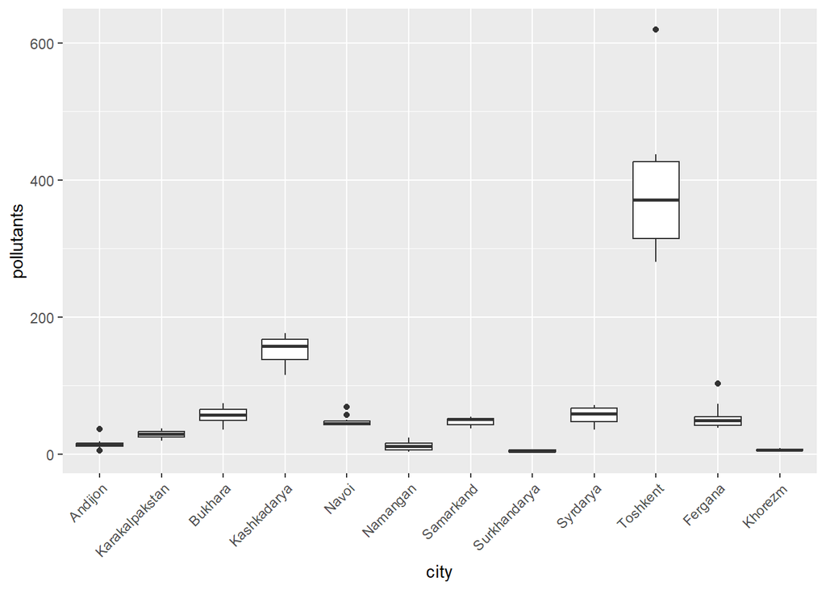

On average, with 12 year Tashkent was distinguished from other regions with the highest produced pollutants to the atmosphere on average annually (about 370 thousand tons on average). The next city on the list with the most produced pollutants within 12 years on average is Kashkadarya, with more than 150 thousand tons (mean). The least “pollutant cities” as the boxplot illustrates are Khorazm, Surkhandarya, Andijan and Namangan.

### Correlation analyis for panel data 1

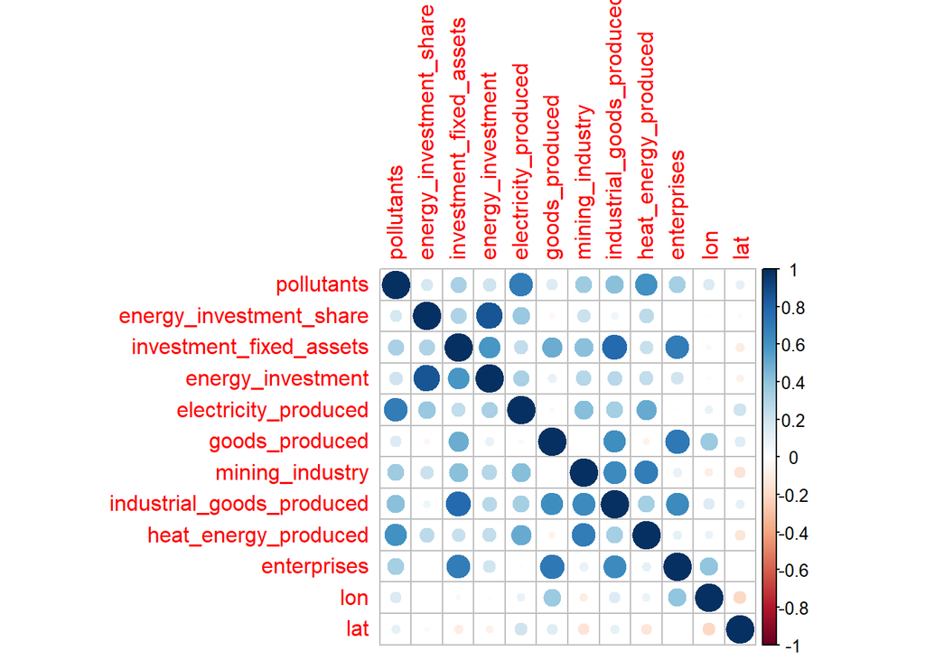

From the correlation plot, we will tak eonly those which have the highest correlation coefficients with the variable “pollutants”.

```r
city <- Data1$city
year <- Data1$year
pollutants <- Data1$pollutants
electricity_produced <- Data1$electricity_produced
industrial_goods_produced <- Data1$industrial_goods_produced
heat_energy_produced <- Data1$heat_energy_produced

Data2 <- data.frame(city,year,pollutants,electricity_produced,industrial_goods_produced,heat_energy_produced)
```

**The new correlation analysis:**

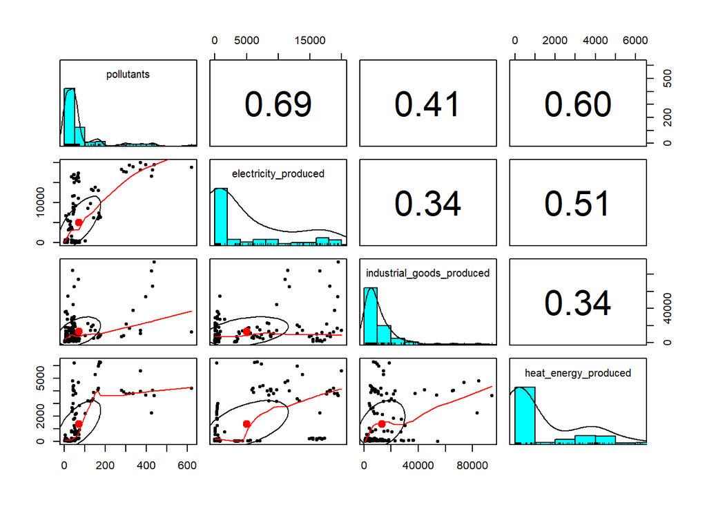

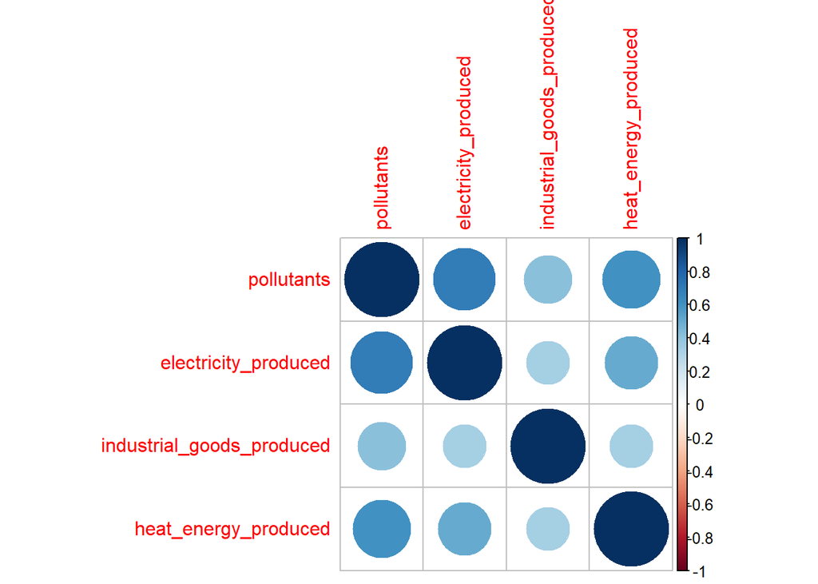

## Data for Model - 2

```r
summarydata <- pdata %>%
  filter(Country != "Denmark")

summary(summarydata[,-c(1,2)])
```

```
##  total_GHG_emissions      GDP            primary_energy_supply  forest_area
##  Min.   : 10.19      Min.   :2.244e+09   Min.   : 2.10         Min.   :1.142
##  1st Qu.: 16.25      1st Qu.:5.817e+09   1st Qu.: 3.15         1st Qu.:2.928
##  Median :101.49      Median :1.552e+10   Median :18.50         Median :6.271
##  Mean   :119.05      Mean   :4.371e+10   Mean   :25.62         Mean   :5.332
##  3rd Qu.:198.09      3rd Qu.:6.042e+10   3rd Qu.:45.23         3rd Qu.:8.054
##  Max.   :360.39      Max.   :2.215e+11   Max.   :81.60         Max.   :8.782
##
##    population       renew_en_consumption urban_population
##  Min.   : 3821782   Min.   : 0.000       Min.   :26.50
##  1st Qu.: 5431750   1st Qu.: 1.035       1st Qu.:35.30
##  Median : 7122904   Median : 1.765       Median :45.55
##  Mean   :12359940   Mean   :16.557       Mean   :43.19
##  3rd Qu.:17351915   3rd Qu.:28.640       3rd Qu.:50.98
##  Max.   :35648100   Max.   :64.580       Max.   :57.99
##                     NA's   :10
```

- **Total GHG Emissions** - The total greenhouse gas emissions (in million metric tons) vary widely across the dataset, with a minimum of 10.19 and a maximum of 360.39. The median value is significantly lower than the mean, suggesting a right-skewed distribution where a few countries or years have exceptionally high GHG emissions.
- **GDP** - The Gross Domestic Product, adjusted to the 2015 USD rate, ranges from a minimum of approximately 2.244 billion to a maximum of 221.5 billion. The large gap between the median and the maximum values indicates significant economic disparities or growth over time within the region.
- **Primary Energy Supply** - This measure shows considerable variation, from 2.10 to 81.60 toe, with a median significantly lower than the mean, indicating a skewed distribution. This suggests that some countries or years have substantially higher energy supplies, possibly reflecting differences in industrialization or energy resource availability (will be discussed later).
- **Forest Area** - Forest area as a percentage of total land area has a relatively narrow range from 1.142% to 8.782%. The median forest area is closer to the upper quartile, indicating that most countries have relatively low forest coverage.
- **Population** - The population sizes vary from about 3.82 million to 35.65 million, highlighting the demographic diversity across the Central Asian countries.
- **Renewable Energy Consumption** - This variable, representing renewable energy consumption as a percentage of total final energy consumption, has missing values for 10 observations. The range is from 0% to 64.58%, indicating a wide variance in renewable energy usage across different countries or years.
- **Urban Population** - The percentage of the urban population ranges from 26.5% to 57.99%, indicating varying degrees of urbanization across the region.

> The longitudinal nature of the data offers an opportunity to study the temporal dynamics of these variables, examining trends, and potential causal relationships over time.

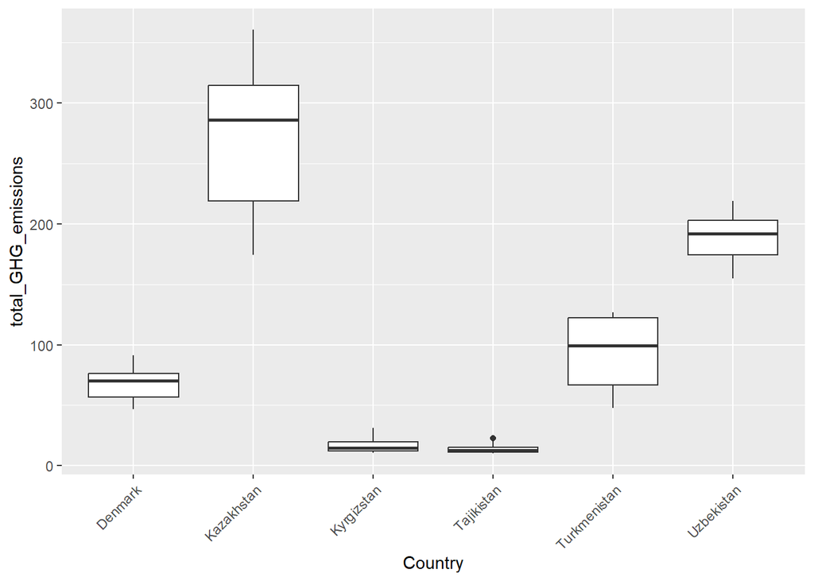

```r
pdata2_df <- data.frame(pdata2)

ggplot(pdata2_df, aes(x = Country, y = total_GHG_emissions)) +
  geom_boxplot() +
  theme(axis.text.x = element_text(angle = 45, hjust = 1))
```

**Kazakhstan:** Has a larger IQR compared to Denmark, indicating more variability in GHG emissions. The median is closer to the top of the IQR, suggesting a skew towards higher emission values.

**Uzbekistan:** This country has IQR in third place in width, indicating the fair variability in GHG emissions among the countries visualized. The median is positioned centrally within the IQR, suggesting a more symmetrical distribution of data points.

Across all countries, the range of GHG emissions (span of the whiskers and outliers) varies significantly, suggesting that there are distinct differences in emission levels and their variance across these countries. The plot also indicates that certain countries like Kyrgyzstan and Tajikistan have consistently low GHG emissions, while countries like Kazakhstan and Uzbekistan exhibit a wider range of emission values.

> This visualization aids in identifying how GHG emissions distribution differs among the countries and can be a starting point for investigating the factors contributing to these differences.

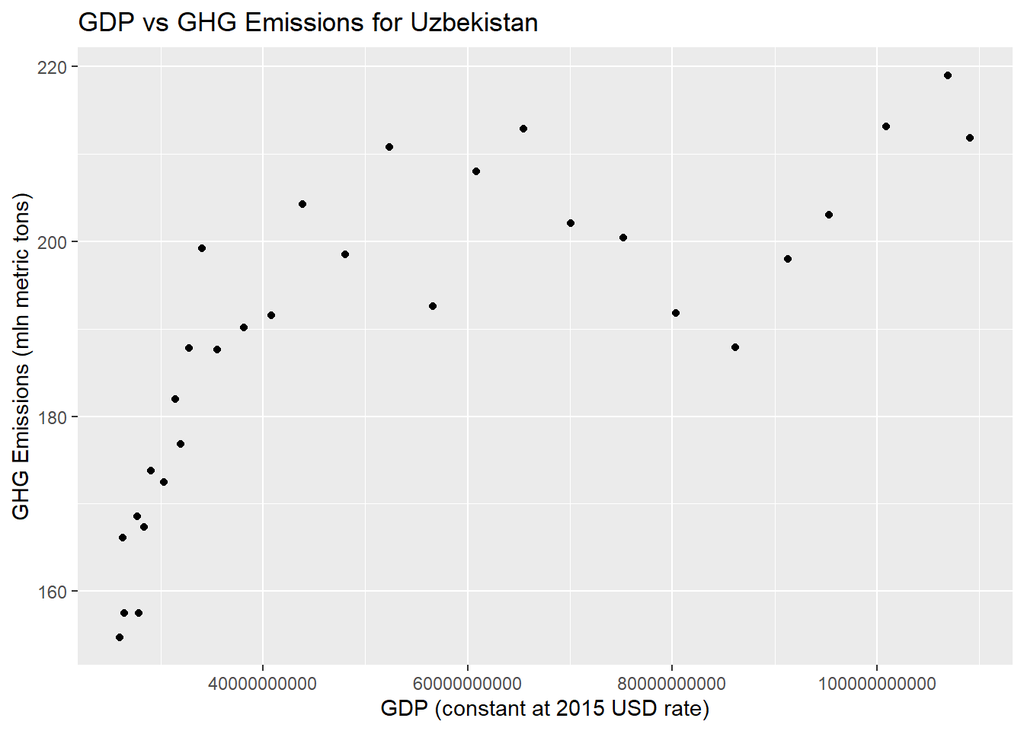

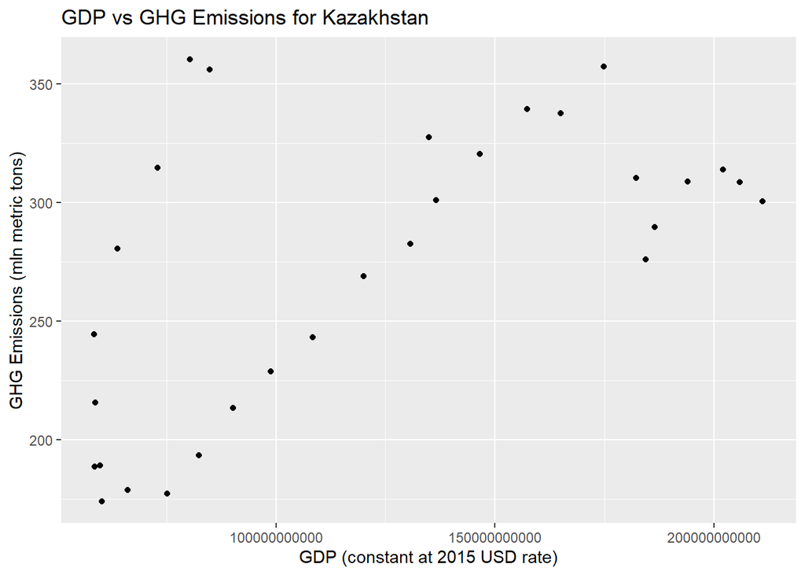

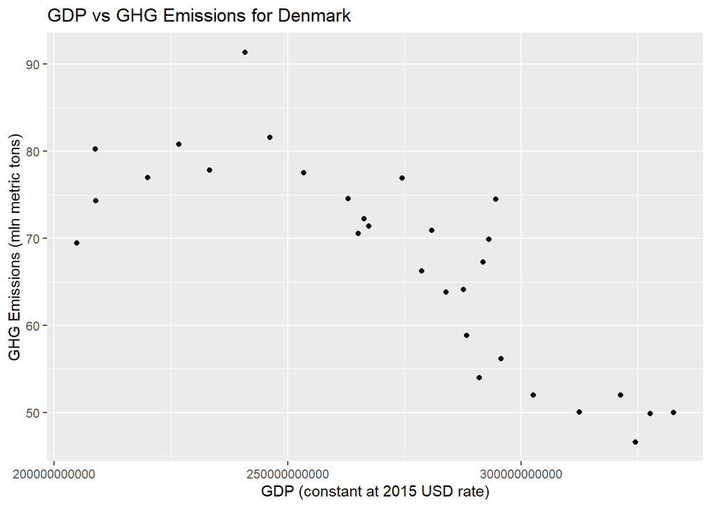

*Graphic of connection of GDP and GHG emisssions within 31 years for each Country is in Appendix E*

The scatter plots for Kazakhstan, Denmark, and Uzbekistan depict the relationship between GDP (constant at 2015 USD rate) and total GHG emissions (in million metric tons). From the visualizations, there seems to be a non-linear relationship between the two variables, potentially indicative of the Environmental Kuznets Curve (EKC) hypothesis.

**The Environmental Kuznets Curve (EKC)**

The EKC hypothesis suggests an inverted U-shaped relationship between environmental degradation (here represented by GHG emissions) and economic growth (indicated by GDP). According to this hypothesis:

1. **Initial Economic Growth:** In the early stages of economic growth, environmental degradation increases as economies prioritize growth over environmental concerns.
2. **Turning Point:** As an economy matures, a turning point is reached where the rate of environmental degradation starts to decrease.
3. **Further Economic Growth:** With further economic development, investment in cleaner technologies and higher environmental regulations leads to a reduction in environmental degradation.

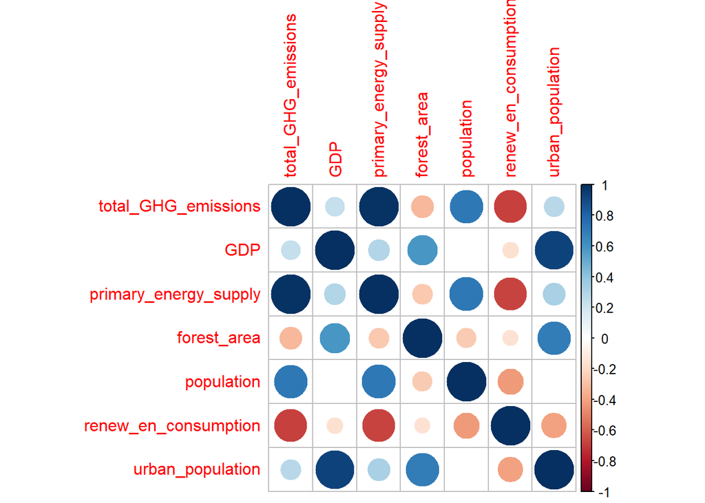

Again, as we have done with the data in previous model, we select only those few variables which correlates a lot with the total GHG emissions and less among themselves.

```r
Country <- panel1$Country
year <- panel1$year
total_GHG_emissions <- panel1$total_GHG_emissions
GDP <- panel1$GDP
primary_energy_supply <- panel1$primary_energy_supply
forest_area <- panel1$forest_area
renew_en_consumption <- panel1$renew_en_consumption

panel2 <- data.frame(Country,year,total_GHG_emissions,GDP,primary_energy_supply,forest_area,renew_en_consumption)
```

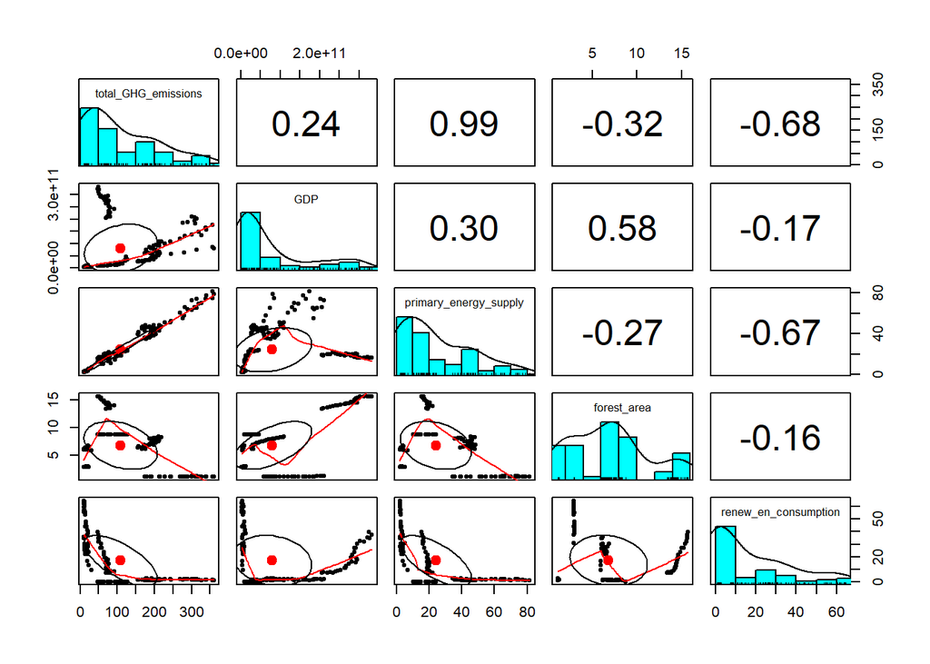

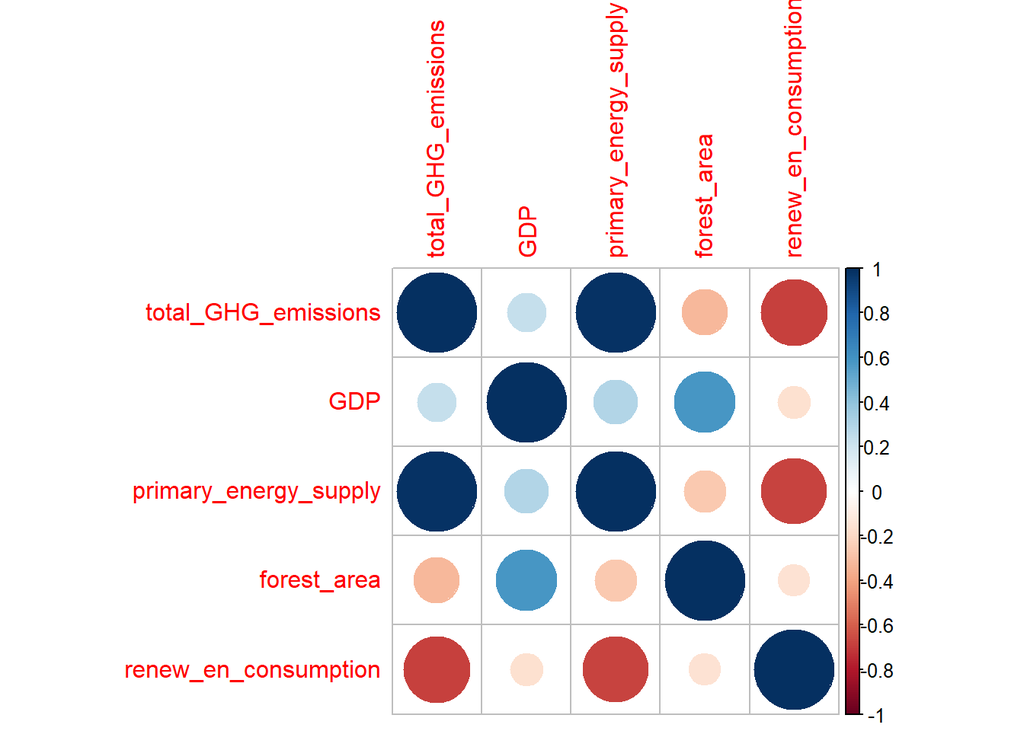

The correlation of GHG emissions with:

**GDP:** - 0.24. A correlation coefficient of 0.24 between GHG emissions and GDP suggests a weak positive relationship. This implies that, in this data set, as GDP increases, GHG emissions tend to increase slightly. Economic growth often leads to increased energy consumption and industrial activity, which can result in higher emissions. However, the weak correlation here might also suggest that the economies could be transitioning towards less emission-intensive activities or becoming more energy-efficient.

> A low correlation between GDP and GHG emissions might imply a decoupling of economic growth from emissions, which is a desirable outcome for sustainable development.

**primary_enery_supply:** - 0.99. A very strong positive correlation of 0.99 indicates an almost one-to-one relationship between primary energy supply and GHG emissions. This is expected since primary energy supply generally includes fossil fuels, which are major sources of GHG emissions. It implies that changes in the level of energy supply are almost directly mirrored by changes in emissions. This could reflect an economy heavily reliant on fossil fuels for energy production.

> The high correlation between primary energy supply and emissions suggests that there is significant room for improvement in energy efficiency or a transition to cleaner energy sources.

**forest_area:** - (-0.32). The negative correlation coefficient indicates an inverse relationship between forest area and GHG emissions. A larger forest area, which serves as a carbon sink, is associated with lower emissions. The moderate strength of the correlation suggests other factors may also play a significant role in determining GHG emissions, but increased forest coverage does contribute to reducing the overall emissions.

**renewable_energy_consumption:** - (-0.68). This moderate negative correlation indicates that higher renewable energy consumption is associated with lower GHG emissions. This suggests that renewables are effectively replacing more carbon-intensive energy sources, leading to a reduction in overall emissions. It may also reflect a broader commitment to sustainable practices and technologies that both increase renewable energy consumption and decrease emissions.

> The negative correlations with forest area and renewable energy consumption align with environmental and green economics principles that advocate for the preservation of natural resources and the adoption of clean energy to mitigate climate impact.

# Building models

## Panel Data - 1

### Heterogeneity across objects and years

Analyzing Heterogeneity Across Cities and Years We begin by exploring the variability in pollution levels, or heterogeneity, across different cities and over time. To do this, we employ the plotmeans function from the gplots package, which graphically displays the means of pollutant levels by city and by year, including 95% confidence intervals around these means. These visualizations are crucial for understanding whether pollution is uniformly distributed across our dataset or whether there are discernible patterns tied to specific locations or periods.

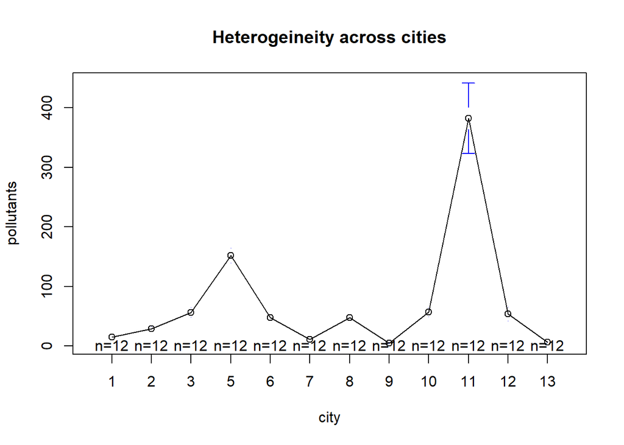

```r
library(gplots)

plotmeans(pollutants ~ city, main="Heterogeineity across cities", data=pdata1)
```

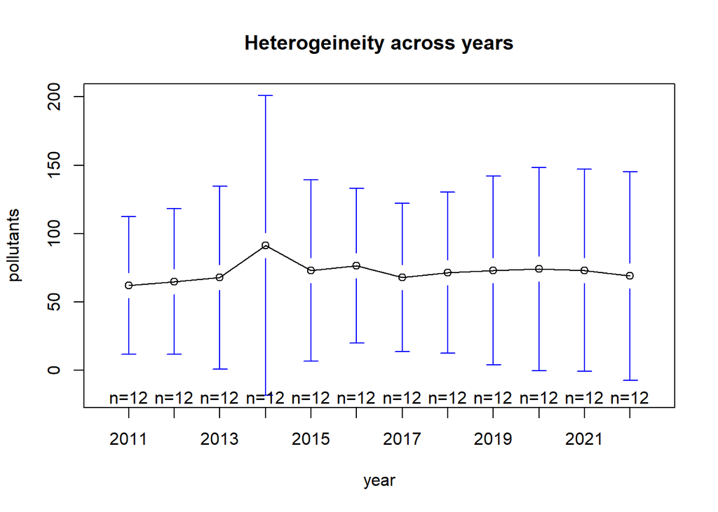

```r
# plotmeans draw a 95% confidence interval around the means

plotmeans(pollutants ~ year, main="Heterogeineity across years", data=pdata1)
```

```r
# plotmeans draw a 95% confidence interval around the means
```

The first diagram illustrates the average levels of pollutants for each city, complete with error bars representing the 95% confidence intervals around these means. A key observation is the presence of a city (labelled as city number 11 - Tahskent) that exhibits a significantly higher average level of pollutants, as indicated by a sharp peak in the graph. The length of the error bars for this city suggests a considerable variation in pollutant levels across the time period studied, implying potential volatility or an uneven distribution of exceptionally high or low values within that city. The remaining cities display relatively lower mean levels of pollutants, with shorter confidence intervals indicating more stable levels over time.

The second diagram focuses on the temporal aspect, displaying the average levels of pollutants across different years. Here, the trend line is relatively flat, indicating that the average pollution levels have not significantly changed during the period under study. However, the length of the error bars, which again denote the 95% confidence intervals, suggests variability in pollution levels from year to year. Some years show wider confidence intervals, highlighting greater uncertainty or variation in pollutant levels during those periods.

### Fixed effects

Next, we shift our focus to a fixed effects model, leveraging the plm package specifically designed for panel data econometrics. We model pollutants as a function of electricity production, industrial goods production, and heat energy production, controlling for the inherent, unobserved characteristics of each city that might influence pollution levels. This “within” model allows us to capture the effect of the variables within each city across the different years.

```r
library(plm)
fix <- plm(pollutants ~ electricity_produced + industrial_goods_produced + heat_energy_produced, data=pdata1, index=c("city", "year"), model="within")
summary(fix)
```

```
## Oneway (individual) effect Within Model
##
## Call:
## plm(formula = pollutants ~ electricity_produced + industrial_goods_produced +
##     heat_energy_produced, data = pdata1, model = "within", index = c("city",
##     "year"))
##
## Balanced Panel: n = 12, T = 12, N = 144
##
## Residuals:
##      Min.   1st Qu.    Median   3rd Qu.      Max.
## -92.46959  -6.79553   0.77256   4.98470 244.24762
##
## Coefficients:
##                              Estimate  Std. Error t-value Pr(>|t|)
## electricity_produced      -0.00131820  0.00184849 -0.7131  0.47706
## industrial_goods_produced  0.00036821  0.00018235  2.0192  0.04554 *
## heat_energy_produced       0.00586785  0.00438614  1.3378  0.18331
## ---
## Signif. codes:  0 '***' 0.001 '**' 0.01 '*' 0.05 '.' 0.1 ' ' 1
##
## Total Sum of Squares:    109050
## Residual Sum of Squares: 104800
## R-Squared:      0.038972
## Adj. R-Squared: -0.065326
## F-statistic: 1.74375 on 3 and 129 DF, p-value: 0.1613
```

The summary function applied to our fixed effects model provides a comprehensive overview of the model’s performance, including coefficients, standard errors, z-values, and p-values for our predictors. We will not delve into analysis yet. After the Hausman test, we will see, which model (FE or RE) will be further analyzed in Results Section.

We also extract the fixed effects using the fixef function, which reveals the unique intercepts for each city, offering insights into city-specific deviations from the average pollution level.

```r
fixef(fix)
```

```
##        1        2        3        5        6        7        8        9
##   7.7368  31.1329  48.3465 132.6175  24.9260  10.6537  43.2699   3.5315
##       10       11       12       13
##  74.7808 370.4836  34.2398   3.3209
```

#### Fixed coefficients

For a more granular view, we also run a classical linear regression with fixed coefficients, including city-specific dummy variables in our regression equation. This approach allows us to estimate the constant term (intercept) for the overall model and the individual deviations for each city from that average.

```r
fe.lm <- lm(pollutants ~ electricity_produced + industrial_goods_produced + heat_energy_produced + factor(city), data =pdata1)
summary(fe.lm)
```

```
##
## Call:
## lm(formula = pollutants ~ electricity_produced + industrial_goods_produced +
##     heat_energy_produced + factor(city), data = pdata1)
##
## Residuals:
##     Min      1Q  Median      3Q     Max
## -92.470  -6.796   0.773   4.985 244.248
##
## Coefficients:
##                             Estimate Std. Error t value Pr(>|t|)
## (Intercept)                7.737e+00  9.027e+00   0.857  0.39298
## electricity_produced      -1.318e-03  1.849e-03  -0.713  0.47706
## industrial_goods_produced  3.682e-04  1.824e-04   2.019  0.04554 *
## heat_energy_produced       5.868e-03  4.386e-03   1.338  0.18331
## factor(city)2              2.340e+01  1.362e+01   1.717  0.08833 .
## factor(city)3              4.061e+01  1.211e+01   3.355  0.00104 **
## factor(city)5              1.249e+02  2.776e+01   4.499  1.5e-05 ***
## factor(city)6              1.719e+01  2.643e+01   0.650  0.51659
## factor(city)7              2.917e+00  1.221e+01   0.239  0.81153
## factor(city)8              3.553e+01  1.177e+01   3.020  0.00305 **
## factor(city)9             -4.205e+00  1.204e+01  -0.349  0.72750
## factor(city)10             6.704e+01  3.193e+01   2.100  0.03770 *
## factor(city)11             3.627e+02  3.822e+01   9.491  < 2e-16 ***
## factor(city)12             2.650e+01  1.592e+01   1.665  0.09835 .
## factor(city)13            -4.416e+00  1.193e+01  -0.370  0.71180
## ---
## Signif. codes:  0 '***' 0.001 '**' 0.01 '*' 0.05 '.' 0.1 ' ' 1
##
## Residual standard error: 28.5 on 129 degrees of freedom
## Multiple R-squared:  0.9333, Adjusted R-squared:  0.9261
## F-statistic:   129 on 14 and 129 DF,  p-value: < 2.2e-16
```

```r
a.0<-fe.lm$coefficients[1];a.0
```

```
## (Intercept)
##    7.736798
```

```r
a.i<-a.0+fe.lm$coefficients[5:15]
a.i
```

```
##  factor(city)2  factor(city)3  factor(city)5  factor(city)6  factor(city)7
##      31.132872      48.346532     132.617452      24.925963      10.653685
##  factor(city)8  factor(city)9 factor(city)10 factor(city)11 factor(city)12
##      43.269865       3.531454      74.780773     370.483560      34.239760
## factor(city)13
##       3.320886
```

### Random Effects

Our research continues with a random effects model, which assumes that the city-specific effects are random and uncorrelated with the predictor variables. After fitting this model, we again call upon the summary function to review the performance and significance of our predictors within this framework.

```r
rand <- plm(pollutants ~ electricity_produced + industrial_goods_produced + heat_energy_produced, data=pdata1, index=c("city", "year"), model="random")
summary(rand)
```

```
## Oneway (individual) effect Random Effect Model
##    (Swamy-Arora's transformation)
##
## Call:
## plm(formula = pollutants ~ electricity_produced + industrial_goods_produced +
##     heat_energy_produced, data = pdata1, model = "random", index = c("city",
##     "year"))
##
## Balanced Panel: n = 12, T = 12, N = 144
##
## Effects:
##                   var std.dev share
## idiosyncratic  812.42   28.50 0.145
## individual    4785.84   69.18 0.855
## theta: 0.8819
##
## Residuals:
##     Min.  1st Qu.   Median  3rd Qu.     Max.
## -62.1845  -8.6640  -3.7159   3.0460 272.6804
##
## Coefficients:
##                             Estimate Std. Error z-value Pr(>|z|)
## (Intercept)               4.6942e+01 2.2861e+01  2.0534  0.04004 *
## electricity_produced      1.4535e-03 1.6621e-03  0.8745  0.38186
## industrial_goods_produced 3.4253e-04 1.8624e-04  1.8392  0.06589 .
## heat_energy_produced      9.3257e-03 4.2356e-03  2.2017  0.02768 *
## ---
## Signif. codes:  0 '***' 0.001 '**' 0.01 '*' 0.05 '.' 0.1 ' ' 1
##
## Total Sum of Squares:    129460
## Residual Sum of Squares: 120920
## R-Squared:      0.065956
## Adj. R-Squared: 0.045941
## Chisq: 9.88584 on 3 DF, p-value: 0.019562
```

### The best model

```r
phtest(fix, rand)
```

```
##
##  Hausman Test
##
## data:  pollutants ~ electricity_produced + industrial_goods_produced +  ...
## chisq = 12.649, df = 3, p-value = 0.005461
## alternative hypothesis: one model is inconsistent
```

### Assumptions

In panel data analysis, ensuring that the model assumptions hold is paramount.

#### Heteroskedasticity

Testing for the presence of heteroskedasticity is also possible in panel settings.The null hypothesis of the Breusch-Pagan test against heteroskedasticity is that homoskedasticity is present.

We test for heteroskedasticity using the Breusch-Pagan test, where the null hypothesis assumes homoskedasticity (constant variance of the error terms). Our findings indicate the presence of heteroskedasticity, suggesting that the variability of pollution levels is not consistent across all observations.

```r
lmtest::bptest(pollutants ~ electricity_produced + industrial_goods_produced + heat_energy_produced + factor(city),
               studentize = F, data = pdata1)
```

```
##
##  Breusch-Pagan test
##
## data:  pollutants ~ electricity_produced + industrial_goods_produced +     heat_energy_produced + factor(city)
## BP = 675.87, df = 14, p-value < 2.2e-16
```

There is an evidence for the presense of heteroskedasticity.

#### Cross-sectional dependence/contemporaneous correlation: using Breusch-Pagan LM test of independence and Pesaran CD test

Utilizing both the Breusch-Pagan LM test and the Pesaran CD test, we identify cross-sectional dependence in our dataset, indicating that there are unaccounted-for common factors influencing pollution levels across different cities.

```r
pcdtest(rand, test = c("lm")) # Breusch-Pagan LM test
```

```
##
##  Breusch-Pagan LM test for cross-sectional dependence in panels
##
## data:  pollutants ~ electricity_produced + industrial_goods_produced +     heat_energy_produced
## chisq = 149.37, df = 66, p-value = 2.106e-08
## alternative hypothesis: cross-sectional dependence
```

```r
pcdtest(rand, test = c("cd")) # Pesaran CD
```

```
##
##  Pesaran CD test for cross-sectional dependence in panels
##
## data:  pollutants ~ electricity_produced + industrial_goods_produced +     heat_energy_produced
## z = 4.7497, p-value = 2.037e-06
## alternative hypothesis: cross-sectional dependence
```

There is a cross-sectional dependence

#### Serial-correlation

We also test for serial correlation, which would suggest a correlation of error terms across time within the same city. Our analysis confirms that serial correlation is present.

```r
pbgtest(rand)
```

```
##
##  Breusch-Godfrey/Wooldridge test for serial correlation in panel models
##
## data:  pollutants ~ electricity_produced + industrial_goods_produced +  ...
## chisq = 33.348, df = 12, p-value = 0.0008542
## alternative hypothesis: serial correlation in idiosyncratic errors
```

There is a serial correlation

#### Statiopnarity test

```r
adf.test(pdata1$pollutants, k=1)
```

```
##
##  Augmented Dickey-Fuller Test
##
## data:  pdata1$pollutants
## Dickey-Fuller = -2.7899, Lag order = 1, p-value = 0.2475
## alternative hypothesis: stationary
```

```r
adf.test(pdata1$electricity_produced, k=1)
```

```
##
##  Augmented Dickey-Fuller Test
##
## data:  pdata1$electricity_produced
## Dickey-Fuller = -2.3098, Lag order = 1, p-value = 0.4475
## alternative hypothesis: stationary
```

```r
adf.test(pdata1$industrial_goods_produced, k=1)
```

```
##
##  Augmented Dickey-Fuller Test
##
## data:  pdata1$industrial_goods_produced
## Dickey-Fuller = -5.132, Lag order = 1, p-value = 0.01
## alternative hypothesis: stationary
```

```r
adf.test(pdata1$heat_energy_produced, k=1)
```

```
##
##  Augmented Dickey-Fuller Test
##
## data:  pdata1$heat_energy_produced
## Dickey-Fuller = -2.3144, Lag order = 1, p-value = 0.4455
## alternative hypothesis: stationary
```

### Opinions about the model

Despite our model failing to meet all the classical assumptions of panel data econometrics, there are noteworthy findings and implications derived from our analysis. These insights will be further elaborated in the conclusion of our research, highlighting the significance of our results and discussing potential strategies to address the identified challenges in future studies.

## Panel Data - 2

We do the same steps for the Panel Data model 2 (except in this model we added the OLS model, not principally affecting the latest results)

### Heterogeneity across objects and years

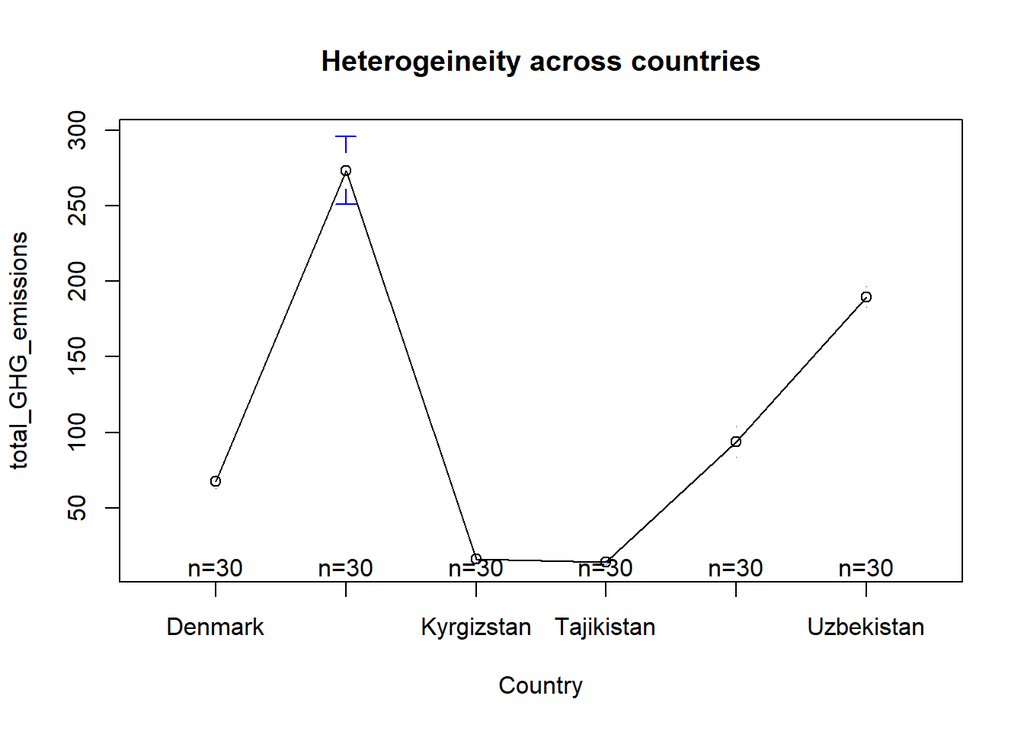

```r
plotmeans(total_GHG_emissions ~ Country, main="Heterogeineity across countries", data=pdata2)
```

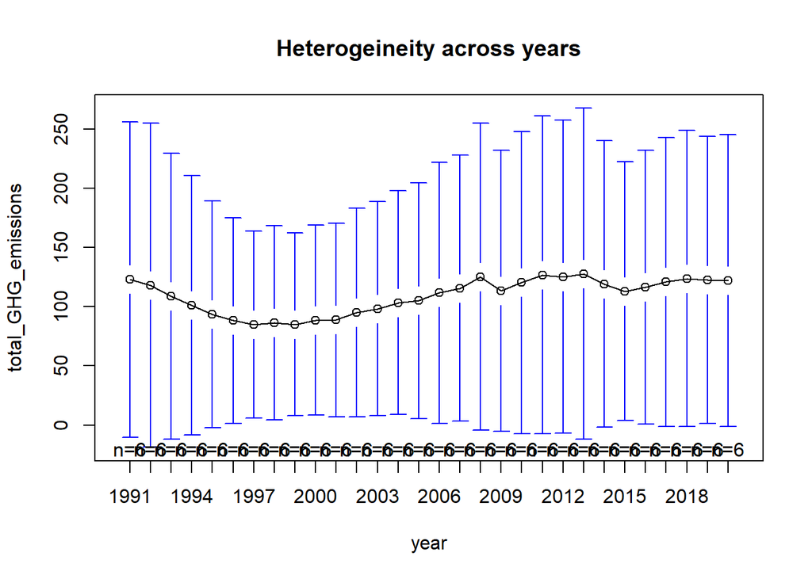

```r
# plotmeans draw a 95% confidence interval around the means

plotmeans(total_GHG_emissions ~ year, main="Heterogeineity across years", data=pdata2)
```

```r
# plotmeans draw a 95% confidence interval around the means
```

> This graph provides a clear visual indication of the variance in pollution levels across countries, which could be attributed to differences in industrial activities, energy use profiles, or environmental policies.

The second graph illustrates the fluctuation of GHG emissions over time, from 1991 to around 2019. We observe a wave-like pattern with no clear upward or downward trend, indicating that average GHG emissions have varied year by year without a consistent direction of change. The confidence intervals are quite wide for most years, which denotes substantial yearly variability in emissions across the countries.

> The trend line does not show a definitive long-term increase or decrease in GHG emissions but rather suggests periods of higher and lower emissions that may correlate with economic cycles, policy changes, energy market shifts, or other temporal factors affecting environmental outcomes.

### OLS регрессия

```r
pdata2$GDP_squared <- pdata2$GDP^2

uzb_data <- pdata2 %>%
  filter(Country == "Uzbekistan")

ols <-lm(log(total_GHG_emissions) ~ log(GDP) + GDP_squared + primary_energy_supply + forest_area + renew_en_consumption, data=uzb_data)
summary(ols)
```

```
##
## Call:
## lm(formula = log(total_GHG_emissions) ~ log(GDP) + GDP_squared +
##     primary_energy_supply + forest_area + renew_en_consumption,
##     data = uzb_data)
##
## Residuals:
##       Min        1Q    Median        3Q       Max
## -0.034766 -0.008509 -0.002430  0.014968  0.035688
##
## Coefficients:
##                         Estimate Std. Error t value Pr(>|t|)
## (Intercept)           -1.633e+00  9.956e-01  -1.640  0.11404
## log(GDP)               2.408e-01  4.613e-02   5.220 2.38e-05 ***
## GDP_squared           -2.172e-23  3.756e-24  -5.784 5.81e-06 ***
## primary_energy_supply  1.271e-02  1.319e-03   9.631 1.02e-09 ***
## forest_area            7.065e-02  2.413e-02   2.928  0.00737 **
## renew_en_consumption  -3.180e-02  1.584e-02  -2.007  0.05611 .
## ---
## Signif. codes:  0 '***' 0.001 '**' 0.01 '*' 0.05 '.' 0.1 ' ' 1
##
## Residual standard error: 0.01981 on 24 degrees of freedom
## Multiple R-squared:  0.9668, Adjusted R-squared:  0.9599
## F-statistic:   140 on 5 and 24 DF,  p-value: < 2.2e-16
```

```r
ols
```

```
##
## Call:
## lm(formula = log(total_GHG_emissions) ~ log(GDP) + GDP_squared +
##     primary_energy_supply + forest_area + renew_en_consumption,
##     data = uzb_data)
##
## Coefficients:
##           (Intercept)               log(GDP)            GDP_squared
##            -1.633e+00              2.408e-01             -2.172e-23
## primary_energy_supply            forest_area   renew_en_consumption
##             1.271e-02              7.065e-02             -3.180e-02
```

## Fixed Effects model

```r
panel_new <- read_excel("panel_new.xlsx")
panel_new <- na.omit(panel_new)
sum(is.na(panel_new))
```

```
## [1] 0
```

```r
pdata3 <- pdata.frame(panel_new)
```

The new panel data is uploaded analogical to panel data of the model 2, but with a change to the variable GPD. In new panel data, it is in 100 million USD (constant 2015)

```r
pdata3$GDP_squared <- pdata3$GDP^2

CA_data <- pdata3 %>%
  filter(Country != "Denmark")

fixed <- plm(log(total_GHG_emissions) ~ log(GDP) + GDP_squared + primary_energy_supply + renew_en_consumption  + urban_population, data=CA_data, index=c("Country", "year"), model="within")
summary(fixed)
```

```
## Oneway (individual) effect Within Model
##
## Call:
## plm(formula = log(total_GHG_emissions) ~ log(GDP) + GDP_squared +
##     primary_energy_supply + renew_en_consumption + urban_population,
##     data = CA_data, model = "within", index = c("Country", "year"))
##
## Balanced Panel: n = 5, T = 30, N = 150
##
## Residuals:
##       Min.    1st Qu.     Median    3rd Qu.       Max.
## -0.2932962 -0.0615900 -0.0069401  0.0550839  0.3156255
##
## Coefficients:
##                          Estimate  Std. Error t-value  Pr(>|t|)
## log(GDP)               2.5230e-01  2.6890e-02  9.3828 < 2.2e-16 ***
## GDP_squared           -1.0385e-07  1.7014e-08 -6.1037 9.614e-09 ***
## primary_energy_supply  1.7103e-02  1.4219e-03 12.0286 < 2.2e-16 ***
## renew_en_consumption  -1.6787e-02  1.7515e-03 -9.5844 < 2.2e-16 ***
## urban_population       1.7105e-02  5.7129e-03  2.9941  0.003255 **
## ---
## Signif. codes:  0 '***' 0.001 '**' 0.01 '*' 0.05 '.' 0.1 ' ' 1
##
## Total Sum of Squares:    8.8962
## Residual Sum of Squares: 1.4018
## R-Squared:      0.84242
## Adj. R-Squared: 0.83229
## F-statistic: 149.693 on 5 and 140 DF, p-value: < 2.22e-16
```

```r
fixed
```

```
##
## Model Formula: log(total_GHG_emissions) ~ log(GDP) + GDP_squared + primary_energy_supply +
##     renew_en_consumption + urban_population
##
## Coefficients:
##              log(GDP)           GDP_squared primary_energy_supply
##            2.5230e-01           -1.0385e-07            1.7103e-02
##  renew_en_consumption      urban_population
##           -1.6787e-02            1.7105e-02
```

## Random Effects model

```r
random <- plm(log(total_GHG_emissions) ~ log(GDP) + GDP_squared + primary_energy_supply + renew_en_consumption, data=pdata3, index=c("Country", "year"), model="random")
summary(random)
```

```
## Oneway (individual) effect Random Effect Model
##    (Swamy-Arora's transformation)
##
## Call:
## plm(formula = log(total_GHG_emissions) ~ log(GDP) + GDP_squared +
##     primary_energy_supply + renew_en_consumption, data = pdata3,
##     model = "random", index = c("Country", "year"))
##
## Balanced Panel: n = 6, T = 30, N = 180
##
## Effects:
##                    var  std.dev share
## idiosyncratic 0.010771 0.103783 0.523
## individual    0.009833 0.099163 0.477
## theta: 0.8123
##
## Residuals:
##      Min.   1st Qu.    Median   3rd Qu.      Max.
## -0.275927 -0.078927  0.019394  0.076614  0.275385
##
## Coefficients:
##                          Estimate  Std. Error  z-value  Pr(>|z|)
## (Intercept)            2.4219e+00  1.4440e-01  16.7727 < 2.2e-16 ***
## log(GDP)               2.9268e-01  2.4413e-02  11.9887 < 2.2e-16 ***
## GDP_squared           -4.7733e-08  1.1654e-08  -4.0959 4.206e-05 ***
## primary_energy_supply  1.7334e-02  1.3717e-03  12.6370 < 2.2e-16 ***
## renew_en_consumption  -1.6385e-02  1.6164e-03 -10.1367 < 2.2e-16 ***
## ---
## Signif. codes:  0 '***' 0.001 '**' 0.01 '*' 0.05 '.' 0.1 ' ' 1
##
## Total Sum of Squares:    18.054
## Residual Sum of Squares: 2.4469
## R-Squared:      0.86447
## Adj. R-Squared: 0.86137
## Chisq: 1116.23 on 4 DF, p-value: < 2.22e-16
```

```r
random
```

```
##
## Model Formula: log(total_GHG_emissions) ~ log(GDP) + GDP_squared + primary_energy_supply +
##     renew_en_consumption
##
## Coefficients:
##           (Intercept)              log(GDP)           GDP_squared
##            2.4219e+00            2.9268e-01           -4.7733e-08
## primary_energy_supply  renew_en_consumption
##            1.7334e-02           -1.6385e-02
```

## Choosing Models

```r
phtest(fixed, random)
```

```
##
##  Hausman Test
##
## data:  log(total_GHG_emissions) ~ log(GDP) + GDP_squared + primary_energy_supply +  ...
## chisq = 20.311, df = 4, p-value = 0.0004335
## alternative hypothesis: one model is inconsistent
```

### Random effects

```r
# Assuming 'random' is your plm model
random_effects <- ranef(random, effect = "individual")

# View the estimated random effects
print(random_effects)
```

```
##      Denmark   Kazakhstan   Kyrgizstan   Tajikistan Turkmenistan   Uzbekistan
##   -0.1873349    0.1961505   -0.4283945   -0.1158202    0.2525338    0.2828653
```

### Assumptions

#### Heteroskedasticity

Testing for the presence of heteroskedasticity is also possible in panel settings.The null hypothesis of the Breusch-Pagan test against heteroskedasticity is that homoskedasticity is present.

```r
lmtest::bptest(log(total_GHG_emissions) ~ log(GDP) + GDP_squared + primary_energy_supply + renew_en_consumption + factor(Country),
               studentize = F, data = pdata3)
```

```
##
##  Breusch-Pagan test
##
## data:  log(total_GHG_emissions) ~ log(GDP) + GDP_squared + primary_energy_supply +     renew_en_consumption + factor(Country)
## BP = 88.725, df = 9, p-value = 2.933e-15
```

There is an evidence for the presense of heteroskedasticity.

#### Cross-sectional dependence/contemporaneous correlation: using Breusch-Pagan LM test of independence and Pesaran CD test

```r
pcdtest(random, test = c("lm")) # Breusch-Pagan LM test
```

```
##
##  Breusch-Pagan LM test for cross-sectional dependence in panels
##
## data:  log(total_GHG_emissions) ~ log(GDP) + GDP_squared + primary_energy_supply +     renew_en_consumption
## chisq = 82.126, df = 15, p-value = 2.848e-11
## alternative hypothesis: cross-sectional dependence
```

```r
pcdtest(random, test = c("cd")) # Pesaran CD
```

```
##
##  Pesaran CD test for cross-sectional dependence in panels
##
## data:  log(total_GHG_emissions) ~ log(GDP) + GDP_squared + primary_energy_supply +     renew_en_consumption
## z = -2.543, p-value = 0.01099
## alternative hypothesis: cross-sectional dependence
```

There is a cross-sectional dependence

#### Serial-correlation

```r
pbgtest(random)
```

```
##
##  Breusch-Godfrey/Wooldridge test for serial correlation in panel models
##
## data:  log(total_GHG_emissions) ~ log(GDP) + GDP_squared + primary_energy_supply +  ...
## chisq = 128.03, df = 30, p-value = 4.481e-14
## alternative hypothesis: serial correlation in idiosyncratic errors
```

There is a serial correlation

#### Statiopnarity test

```r
adf.test(pdata3$total_GHG_emissions, k=3)
```

```
##
##  Augmented Dickey-Fuller Test
##
## data:  pdata3$total_GHG_emissions
## Dickey-Fuller = -2.1608, Lag order = 3, p-value = 0.509
## alternative hypothesis: stationary
```

```r
adf.test(pdata3$GDP, k=1)
```

```
##
##  Augmented Dickey-Fuller Test
##
## data:  pdata3$GDP
## Dickey-Fuller = -1.877, Lag order = 1, p-value = 0.6276
## alternative hypothesis: stationary
```

```r
adf.test(pdata3$GDP_squared, k=1)
```

```
##
##  Augmented Dickey-Fuller Test
##
## data:  pdata3$GDP_squared
## Dickey-Fuller = -2.607, Lag order = 1, p-value = 0.3225
## alternative hypothesis: stationary
```

```r
adf.test(pdata3$primary_energy_supply, k=1)
```

```
##
##  Augmented Dickey-Fuller Test
##
## data:  pdata3$primary_energy_supply
## Dickey-Fuller = -2.4083, Lag order = 1, p-value = 0.4056
## alternative hypothesis: stationary
```

```r
adf.test(pdata3$renew_en_consumption, k=1)
```

```
##
##  Augmented Dickey-Fuller Test
##
## data:  pdata3$renew_en_consumption
## Dickey-Fuller = -1.7516, Lag order = 1, p-value = 0.68
## alternative hypothesis: stationary
```

### Opinions about the model

Even if the model failed in the assumptions test, there are still some important points worth paying attention in this panel data set. They will be discussed in the results and conclusion part.

# Results

A significant challenge yet an attractive feature of panel data models is addressing unseen variability. Traditional approaches like fixed or random effects models tackle this by introducing dummy variables or making specific assumptions about the model’s error structure (refer to Baltagi (2005) for examples). In both scenarios, these models presuppose that the unseen variability does not change over time for each entity, except for a possible overarching time trend. While this premise may hold for panel datasets with a relatively short time span, it often becomes less tenable in datasets that span over longer periods [13].

Both models analysed here are within the range of 12 years and 31 years respectively. Compared to huge databases of developed countries, the newly independent countries of the Central Asia have a data time range at maximum 34-35 years. At the same time, the main question of the research (to find, What are the main factors and drivers that influence Uzbekistan’s transition to a green economy and green growth?) indicates to finding only the main variables and their influence towards the green growth in Uzbekistan (and other Central Asian countries), thus the condition of stationarity is not observed.

```r
summary(rand)
```

```
## Oneway (individual) effect Random Effect Model
##    (Swamy-Arora's transformation)
##
## Call:
## plm(formula = pollutants ~ electricity_produced + industrial_goods_produced +
##     heat_energy_produced, data = pdata1, model = "random", index = c("city",
##     "year"))
##
## Balanced Panel: n = 12, T = 12, N = 144
##
## Effects:
##                   var std.dev share
## idiosyncratic  812.42   28.50 0.145
## individual    4785.84   69.18 0.855
## theta: 0.8819
##
## Residuals:
##     Min.  1st Qu.   Median  3rd Qu.     Max.
## -62.1845  -8.6640  -3.7159   3.0460 272.6804
##
## Coefficients:
##                             Estimate Std. Error z-value Pr(>|z|)
## (Intercept)               4.6942e+01 2.2861e+01  2.0534  0.04004 *
## electricity_produced      1.4535e-03 1.6621e-03  0.8745  0.38186
## industrial_goods_produced 3.4253e-04 1.8624e-04  1.8392  0.06589 .
## heat_energy_produced      9.3257e-03 4.2356e-03  2.2017  0.02768 *
## ---
## Signif. codes:  0 '***' 0.001 '**' 0.01 '*' 0.05 '.' 0.1 ' ' 1
##
## Total Sum of Squares:    129460
## Residual Sum of Squares: 120920
## R-Squared:      0.065956
## Adj. R-Squared: 0.045941
## Chisq: 9.88584 on 3 DF, p-value: 0.019562
```

The First model is distinguished with certain drawbacks:

- The insignificant Adjusted $R^2=0.046$. That means the model needs to be complemented with new more relatable variables other than from the dataset provided. This is the foundation for the further researchers to think about before collecting the exactly same dataset for panel data;
- The insignificant coefficient of the variable “electricity_produced”;
- Multicollinearity: variables “electricity_produced” and “heat_energy_produced” have the coefficient of correlation 0.51, significant enough to lead to some distortions in the model;
- The Assumtions tests: When it comes to cross-sectional and serial correlation, the model did not pass the tests, thus, at this for, Random effects model 1 cannot be used.

```r
summary(random)
```

```
## Oneway (individual) effect Random Effect Model
##    (Swamy-Arora's transformation)
##
## Call:
## plm(formula = log(total_GHG_emissions) ~ log(GDP) + GDP_squared +
##     primary_energy_supply + renew_en_consumption, data = pdata3,
##     model = "random", index = c("Country", "year"))
##
## Balanced Panel: n = 6, T = 30, N = 180
##
## Effects:
##                    var  std.dev share
## idiosyncratic 0.010771 0.103783 0.523
## individual    0.009833 0.099163 0.477
## theta: 0.8123
##
## Residuals:
##      Min.   1st Qu.    Median   3rd Qu.      Max.
## -0.275927 -0.078927  0.019394  0.076614  0.275385
##
## Coefficients:
##                          Estimate  Std. Error  z-value  Pr(>|z|)
## (Intercept)            2.4219e+00  1.4440e-01  16.7727 < 2.2e-16 ***
## log(GDP)               2.9268e-01  2.4413e-02  11.9887 < 2.2e-16 ***
## GDP_squared           -4.7733e-08  1.1654e-08  -4.0959 4.206e-05 ***
## primary_energy_supply  1.7334e-02  1.3717e-03  12.6370 < 2.2e-16 ***
## renew_en_consumption  -1.6385e-02  1.6164e-03 -10.1367 < 2.2e-16 ***
## ---
## Signif. codes:  0 '***' 0.001 '**' 0.01 '*' 0.05 '.' 0.1 ' ' 1
##
## Total Sum of Squares:    18.054
## Residual Sum of Squares: 2.4469
## R-Squared:      0.86447
## Adj. R-Squared: 0.86137
## Chisq: 1116.23 on 4 DF, p-value: < 2.22e-16
```

The second model seems to have more favorable outcomes than the first model:

**Equation of the RE-2 model**

Based on summary output from the Random Effects model 2, the equation for our model can be represented as follows:

$$log(total GHG emissions_{it}) = 2.4219 +
0.29268 \cdot log(GDP_{it}) + -4.7733 \cdot 10^{-8} \cdot (GDP_{it}^2) +$$

$$+ 0.017334 \cdot (primary energy
supply_{it}) -0.016385 \cdot (renewable energy consumption_{it}) + u_{i}
+ \epsilon_{it}$$

*total_GHG_emissions and GDP are in natural log form*

Where:

- $u_{i}$ -is the unobserved country-specific random effect;

*Country specific effects:*

```
##      Denmark   Kazakhstan   Kyrgizstan   Tajikistan Turkmenistan   Uzbekistan
##   -0.1873349    0.1961505   -0.4283945   -0.1158202    0.2525338    0.2828653
```

- $\epsilon_{it}$ - is the idiosyncratic error term.

*Idiosyncratic error term for each country in each year is provided in the Appendix F*

## Model 1 (complementary analysis)

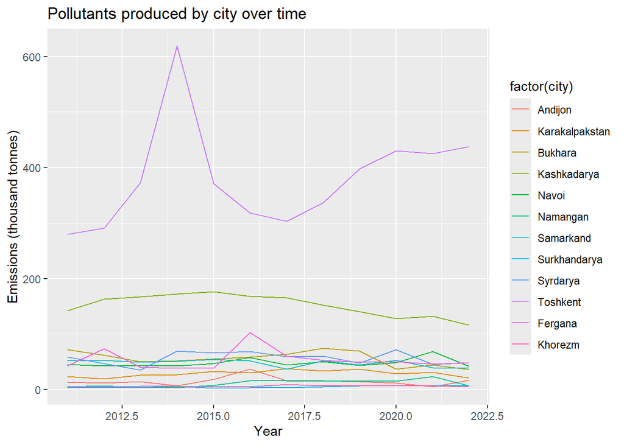

The first chart exhibits Tashkent as having the highest GHG emissions among the listed cities, indicating its significant contribution to the overall environmental footprint of the region. Tashkent’s emission line shows variability over time, with a notable peak, suggesting a possible event or change in that particular year that caused emissions to spike. Kashkadarya is represented by the lower green line and shows relatively low emissions compared to Tashkent. This indicates that Kashkadarya’s industrial activities or energy consumption may be lower, or that the city has more effective pollution control measures in place. Other cities produce relatively lower GHG emissions.

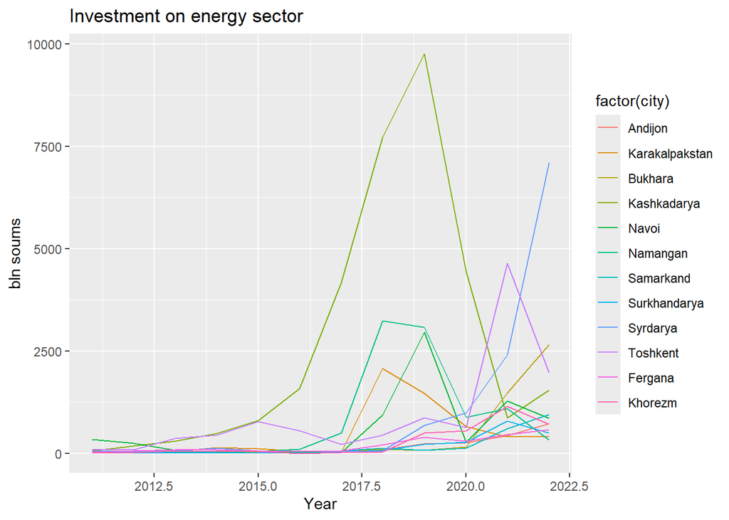

The second line chart presented shows the investment in the energy sector, measured in billion soums, for various cities over a period from 2011 to approximately 2022. There are significant fluctuations in investment across different years and cities. There are notable peaks for certain cities, such as the pronounced spike for Kashkadarya in 2019, indicating a year of heavy investment. This could be due to a specific project or initiative that required substantial funding. Similar observations can be made for other cities that show significant, albeit less extreme, peaks, such as Namangan, Navoi and Karakalpakstan in 2018-2019.

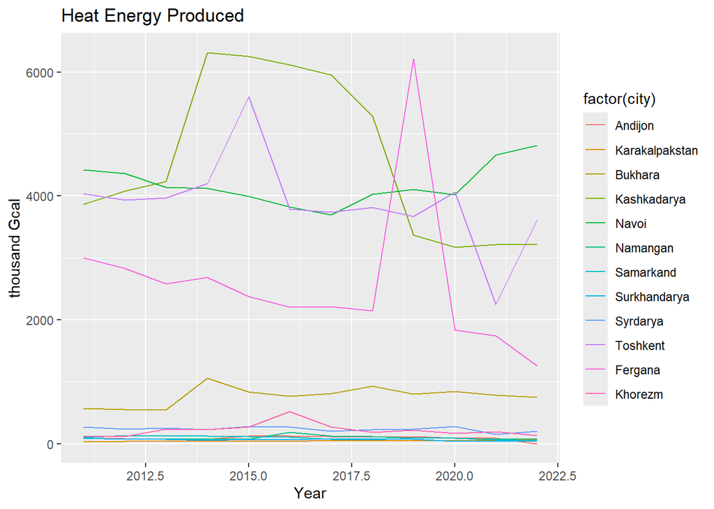

*Graphic of changes of other variables within 12 years for each city is in Appendix G*

## Model 2 (complementary analysis)

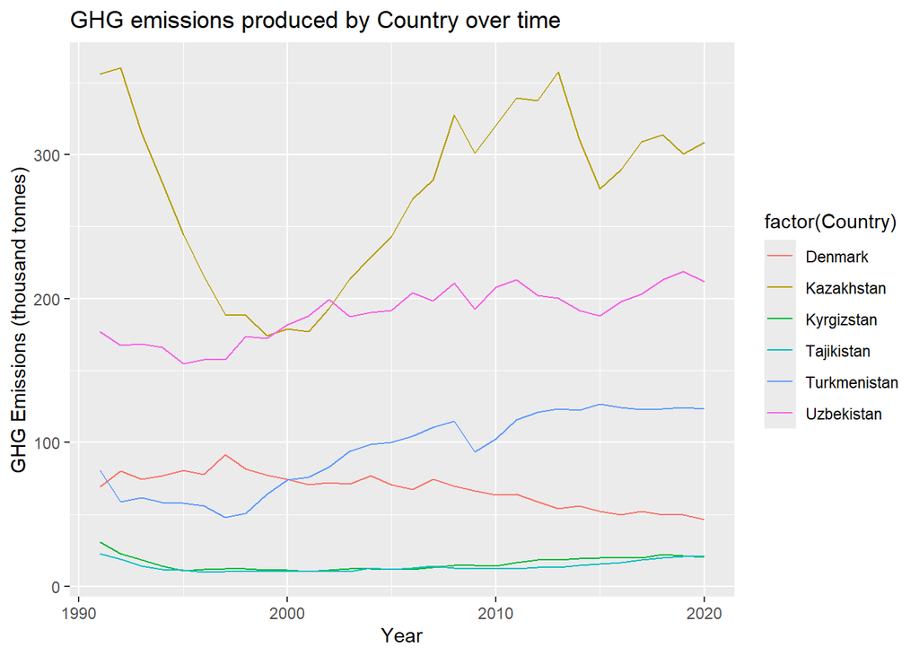

The line chart depicts the greenhouse gas (GHG) emissions produced by each of the six countries over time, measured in thousand tonnes from 1991 to approximately 2020.

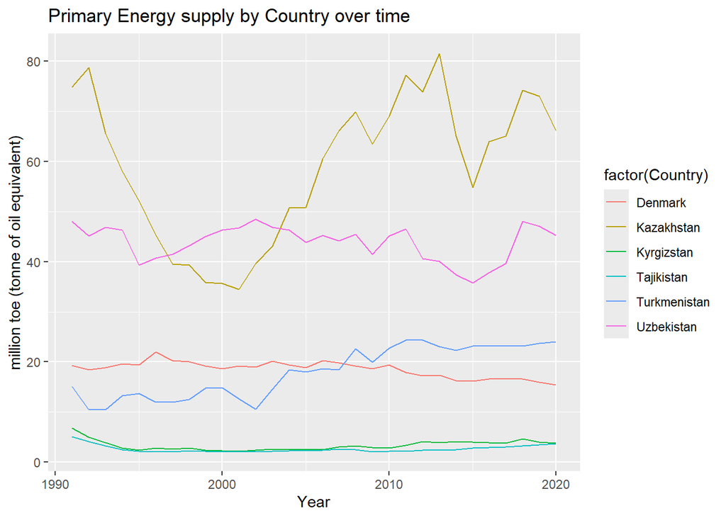

The graph illustrates the primary energy supply by country over time, measured in million tonnes of oil equivalent (toe) from 1991 to approximately 2021.

> **Uzbekistan:** The Primary Energy supply in Uzbekistan fluctuates along the 45 mln toe within the last 31 years. However, this indicator started to increase since 2015. The previous graph also indicated the same pattern.

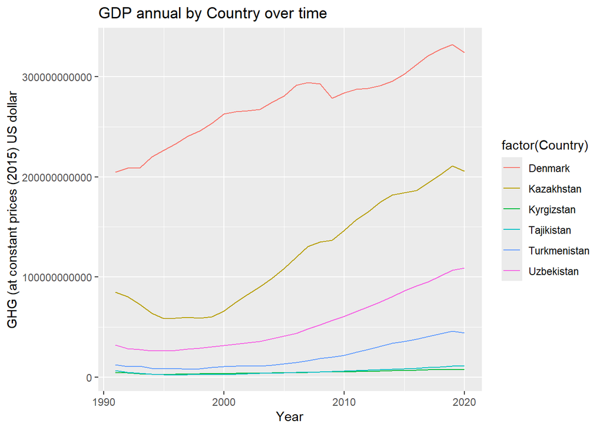

The graph shows the GDP annual growth by country over time in constant 2015 U.S. dollars from 1991 to approximately 2021.

**Denmark’s Economic Growth:** Denmark’s GDP shows a consistent upward trend, with some fluctuations, which indicates steady economic growth. Despite this growth, previous graphs have shown that Denmark’s GHG emissions and primary energy supply have remained relatively stable or declined, suggesting effective decoupling of economic growth from environmental impact.

**Kazakhstan’s GDP and Energy Relationship:** Kazakhstan exhibits a substantial increase in GDP over time. When this trend is compared with the earlier analyses, we see that Kazakhstan’s rise in GDP is accompanied by significant fluctuations in both GHG emissions and primary energy supply. This suggests that economic growth in Kazakhstan may be largely driven by energy-intensive industries.

> When connected with the previous analyses, it’s apparent that there are different models of economic development and their corresponding environmental impacts among these countries. Denmark is an example of high economic development with a focus on sustainability, while the Central Asian countries appear to follow a more traditional model where economic growth is associated with increased GHG emissions and energy supply.

*Graphic of other variables for each Country is in Appendix H*

## Conclusion

The empirical analysis of GHG emissions across countries underscores the intricate relationship between economic activity, energy consumption, and environmental impact. The positive coefficient on log(GDP) confirms the hypothesis that economic expansion, as measured by GDP, exerts upward pressure on GHG emissions, corroborating the conventional narrative linking economic growth with environmental degradation. This coefficient indicates that *a 1% increase in GDP is associated with an approximately 0.293% increase in total GHG emissions*. The positive sign signifies that GHG emissions tend to increase with rising GDP.

**However, the emergence of a negative coefficient on the squared GDP term introduces a non-linear dynamic, suggestive of the Environmental Kuznets Curve (EKC) hypothesis**, which posits that emissions initially increase with economic growth up to a turning point, beyond which they decline. This inflection point is critical, reflecting a threshold at which a country’s development reaches a stage where increased income allows for and supports cleaner technologies and stricter environmental regulation, thereby reducing emissions despite continued economic growth.

Furthermore, the model reveals that a unit increase in primary energy supply, dominantly from non-renewable sources, significantly raises GHG emissions, reinforcing the energy-emissions nexus. This suggests that **for each additional unit (million toe) of primary energy supply, GHG emissions increase by 1.7334%**. This reflects the direct relationship between energy supply and emissions.

Contrastingly, renewable energy consumption emerges as a pivotal factor in mitigating emissions. The negative sign of the coefficient for renewable energy consumption indicates that transitioning to green energy plays a substantial role in curtailing emissions, aligning with sustainable development goals. **The negative coefficient means that increasing renewable energy consumption is associated with a decrease in GHG emissions by 1.6385%. This highlights the beneficial impact of renewable energy on reducing emissions.**

Country-specific effects, encapsulated in the random effects model, attest to the critical role of nation-specific policies, resource endowments, and technological advancements in determining the GHG emissions profile. These effects, coupled with a robust R-squared, signify that a considerable share of the variance in emissions is explained by the model’s variables, cementing the relationship between the examined predictors and emissions. The statistical significance of all coefficients further reinforces the reliability of the model, thereby providing a credible framework for policymakers to scrutinize the energy-growth-emissions triad while strategizing for economic advancement in an environmentally sustainable manner.

## Notes and key points

- **Economic Growth:** There is a strong and statistically significant relationship between GDP and GHG emissions. As economies grow, they tend to produce more emissions, but the relationship is not linear; at higher levels of GDP, the increase in emissions starts to slow down, which may suggest that countries begin to implement more efficient or cleaner technologies as they become wealthier.
- **Energy Supply and Renewables:** The direct correlation between primary energy supply and emissions underscores the impact of energy production methods on GHG emissions. Simultaneously, the negative coefficient for renewable energy consumption confirms the importance of renewables in reducing emissions.
- **Policy Implications:** The significant coefficients for GDP, primary energy supply, and renewable energy consumption imply that policies promoting economic growth and energy supply must be balanced with environmental considerations. Specifically, investment in renewable energy sources is validated as an effective measure to combat rising GHG emissions.
- **Model Limitations:** Despite the high R-squared, the presence of cross-sectional and serial correlation means the model could be improved. Future models could apply techniques like panel-corrected standard errors (PCSE) or generalized method of moments (GMM) to address these issues.

# References

1. UNEP (2015) Uncovering pathways towards an inclusive green economy: a summary for leaders. Available at: https://www.unep.org/resources/report/uncovering-pathways-towards-inclusive-green-economy-summary-leaders (Accessed: 9 March 2024).
2. World Bank (2022) Towards a greener economy in Uzbekistan. Available at: https://openknowledge.worldbank.org/entities/publication/7046a76c-f533-5846-83e4-7dde22f2ad03 (Accessed: 9 March 2024).
3. UNDP. (2023). Uzbekistan | United Nations Development Programme. [online] Available at: https://www.undp.org/uzbekistan. (Accessed: 9 March 2024).
4. Environment, U.N. (2017). Why does green economy matter? [online] UNEP - UN Environment Programme. Available at: https://www.unep.org/explore-topics/green-economy/why-does-green-economy-matter. (Accessed: 10 March 2024).
5. Natali, C. (2009). Aristotle: Nicomachean ethics. Book VII. Oxford ; New York: Oxford University Press.
6. Plato (2008). The Republic. Oxford: Oxford University Press.
7. OWD (2023), “CO2 emissions”, Our World in Data (database), https://ourworldindata.org/co2-emissions (Accessed 10 March 2024).
8. Mirkasimov, B. et al. (2023), “Determinants of carbon emission and the potential economic impact of ‘green’ economy strategies” in Central Asia: Kazakhstan and Uzbekistan, CAREC Institute, Chapter-5.pdf [carecinstitute.org](https://www.carecinstitute.org/wp-content/uploads/2023/01/Chapter-5.pdf)
9. Baltagi, B.H., (2005). Econometric Analysis of Panel Data, 3rd ed. Wiley.
10. Croissant, Y. and Millo, G., n.d. Panel data econometrics in R: The plm package. [online] CRAN R-Project. Available at: https://cran.r-project.org/web/packages/plm/vignettes/A_plmPackage.html [Accessed 11 March 2024].
11. Bates, D., Mächler, M., Bolker, B., and Walker, S., 2015. Fitting Linear Mixed-Effects Models Using lme4. Journal of Statistical Software, 67(1), pp.1-48.
12. Pinheiro, J., Bates, D., DebRoy, S., Sarkar, D. and R Core Team, 2020. nlme: Linear and Nonlinear Mixed Effects Models. R package version 3.1-149.
13. Oualid B. Dominik L., (2014) Panel Data Analysis with R and the plm Package. [pdf] Available at: https://cran.r-hub.io/web/packages/phtt/vignettes/phtt.pdf [Accessed 12 March 2024].

# Appendix

## A

```r
pdata1
```

[output not shown]

[output cut: 380 more lines]

```
## 12-2020                 21701.212           1835.08054       35379 71.78 40.39
## 12-2021                 27761.487           1744.92400       42241 71.78 40.39
## 12-2022                 30303.452           1257.61700       46622 71.78 40.39
## 13-2011                   852.400            120.20000       10822 60.63 41.55
## 13-2012                  1014.200            112.40000       12044 60.63 41.55
## 13-2013                  1297.200            236.90000       12043 60.63 41.55
## 13-2014                  1920.800            226.78000       12502 60.63 41.55
## 13-2015                  2616.000            269.60000       13003 60.63 41.55
## 13-2016                  2802.700            519.60000       12899 60.63 41.55
## 13-2017                  4070.400            267.10000       13342 60.63 41.55
## 13-2018                  6457.200            181.23000       13674 60.63 41.55
## 13-2019                  8538.600            216.98400       14837 60.63 41.55
## 13-2020                  9615.902            166.90700       18614 60.63 41.55
## 13-2021                 13658.092            194.03100       21979 60.63 41.55
## 13-2022                 18323.319            136.96770       25160 60.63 41.55
```

## B

```r
pdata2
```

```
##                        Country year total_GHG_emissions          GDP
## Denmark-1991           Denmark 1991            69.45756 204829791576
## Denmark-1992           Denmark 1992            80.25455 208838324345
## Denmark-1993           Denmark 1993            74.30220 208860644215
## Denmark-1994           Denmark 1994            76.97669 219998060186
## Denmark-1995           Denmark 1995            80.80877 226658693445
## Denmark-1996           Denmark 1996            77.83495 233232021689
## Denmark-1997           Denmark 1997            91.38676 240837461729
## Denmark-1998           Denmark 1998            81.59790 246179618941
## Denmark-1999           Denmark 1999            77.53103 253437048662
## Denmark-2000           Denmark 2000            74.54629 262932986642
## Denmark-2001           Denmark 2001            70.57111 265097327404
## Denmark-2002           Denmark 2002            72.23269 266333597051
## Denmark-2003           Denmark 2003            71.42266 267372454035
## Denmark-2004           Denmark 2004            76.94163 274506537369
## Denmark-2005           Denmark 2005            70.90034 280920770515
## Denmark-2006           Denmark 2006            67.25702 291913222678
## Denmark-2007           Denmark 2007            74.48263 294567411335
## Denmark-2008           Denmark 2008            69.87573 293059176864
## Denmark-2009           Denmark 2009            66.22115 278680088475
## Denmark-2010           Denmark 2010            63.80623 283894168260
## Denmark-2011           Denmark 2011            64.14703 287689202383
## Denmark-2012           Denmark 2012            58.83455 288340817827
## Denmark-2013           Denmark 2013            53.97483 291032020820
## Denmark-2014           Denmark 2014            56.15586 295744975353
## Denmark-2015           Denmark 2015            51.99106 302673070847
## Denmark-2016           Denmark 2016            50.05238 312497708532
## Denmark-2017           Denmark 2017            52.00210 321315569940
## Denmark-2018           Denmark 2018            49.83877 327708263103
## Denmark-2019           Denmark 2019            49.97799 332602543274
## Denmark-2020           Denmark 2020            46.61909 324538552443
## Kazakhstan-1991     Kazakhstan 1991           355.99353  84840573793
## Kazakhstan-1992     Kazakhstan 1992           360.39462  80344023383
## Kazakhstan-1993     Kazakhstan 1993           314.62743  72952373230
## Kazakhstan-1994     Kazakhstan 1994           280.54717  63760374204
## Kazakhstan-1995     Kazakhstan 1995           244.39632  58532023519
## Kazakhstan-1996     Kazakhstan 1996           215.65629  58824683638
## Kazakhstan-1997     Kazakhstan 1997           189.05388  59824703259
## Kazakhstan-1998     Kazakhstan 1998           188.54275  58688033898
## Kazakhstan-1999     Kazakhstan 1999           174.10420  60272610812
```

[output cut: 488 more lines]

```
## Uzbekistan-2006                   0.85           49.021 1.924615e+21
## Uzbekistan-2007                   0.90           49.505 2.306524e+21
## Uzbekistan-2008                   0.80           49.989 2.741848e+21
## Uzbekistan-2009                   1.25           50.472 3.201109e+21
## Uzbekistan-2010                   1.35           50.956 3.705972e+21
## Uzbekistan-2011                   0.95           51.150 4.284717e+21
## Uzbekistan-2012                   1.34           51.050 4.914970e+21
## Uzbekistan-2013                   1.19           50.950 5.658384e+21
## Uzbekistan-2014                   1.40           50.850 6.463016e+21
## Uzbekistan-2015                   1.71           50.750 7.429796e+21
## Uzbekistan-2016                   1.61           50.650 8.337435e+21
## Uzbekistan-2017                   1.75           50.550 9.086448e+21
## Uzbekistan-2018                   1.49           50.478 1.018638e+22
## Uzbekistan-2019                   1.56           50.433 1.144144e+22
## Uzbekistan-2020                   1.03           50.416 1.190264e+22
```

## C

```r
str(pdata1)
```

```
## Classes 'pdata.frame' and 'data.frame':  144 obs. of  14 variables:
##  $ city                     : Factor w/ 12 levels "1","2","3","5",..: 1 1 1 1 1 1 1 1 1 1 ...
##   ..- attr(*, "names")= chr [1:144] "1-2011" "1-2012" "1-2013" "1-2014" ...
##   ..- attr(*, "index")=Classes 'pindex' and 'data.frame':    144 obs. of  2 variables:
##   .. ..$ city: Factor w/ 12 levels "1","2","3","5",..: 1 1 1 1 1 1 1 1 1 1 ...
##   .. ..$ year: Factor w/ 12 levels "2011","2012",..: 1 2 3 4 5 6 7 8 9 10 ...
##  $ year                     : Factor w/ 12 levels "2011","2012",..: 1 2 3 4 5 6 7 8 9 10 ...
##   ..- attr(*, "names")= chr [1:144] "1-2011" "1-2012" "1-2013" "1-2014" ...
##   ..- attr(*, "index")=Classes 'pindex' and 'data.frame':    144 obs. of  2 variables:
##   .. ..$ city: Factor w/ 12 levels "1","2","3","5",..: 1 1 1 1 1 1 1 1 1 1 ...
##   .. ..$ year: Factor w/ 12 levels "2011","2012",..: 1 2 3 4 5 6 7 8 9 10 ...
##  $ pollutants               : 'pseries' Named num  13.6 12.2 14.4 6.6 18.5 36.7 15.8 15.9 14.3 11.5 ...
##   ..- attr(*, "names")= chr [1:144] "1-2011" "1-2012" "1-2013" "1-2014" ...
##   ..- attr(*, "index")=Classes 'pindex' and 'data.frame':    144 obs. of  2 variables:
##   .. ..$ city: Factor w/ 12 levels "1","2","3","5",..: 1 1 1 1 1 1 1 1 1 1 ...
##   .. ..$ year: Factor w/ 12 levels "2011","2012",..: 1 2 3 4 5 6 7 8 9 10 ...
##  $ energy_investment_share  : 'pseries' Named num  0.024 0.033 0.022 0.02 0.016 0.031 0.019 0.02 0.032 0.027 ...
##   ..- attr(*, "names")= chr [1:144] "1-2011" "1-2012" "1-2013" "1-2014" ...
##   ..- attr(*, "index")=Classes 'pindex' and 'data.frame':    144 obs. of  2 variables:
##   .. ..$ city: Factor w/ 12 levels "1","2","3","5",..: 1 1 1 1 1 1 1 1 1 1 ...
##   .. ..$ year: Factor w/ 12 levels "2011","2012",..: 1 2 3 4 5 6 7 8 9 10 ...
##  $ investment_fixed_assets  : 'pseries' Named num  1037 1380 1462 1645 1956 ...
##   ..- attr(*, "names")= chr [1:144] "1-2011" "1-2012" "1-2013" "1-2014" ...
##   ..- attr(*, "index")=Classes 'pindex' and 'data.frame':    144 obs. of  2 variables:
##   .. ..$ city: Factor w/ 12 levels "1","2","3","5",..: 1 1 1 1 1 1 1 1 1 1 ...
##   .. ..$ year: Factor w/ 12 levels "2011","2012",..: 1 2 3 4 5 6 7 8 9 10 ...
##  $ energy_investment        : 'pseries' Named num  24.9 45.5 32.2 32.9 31.3 ...
##   ..- attr(*, "names")= chr [1:144] "1-2011" "1-2012" "1-2013" "1-2014" ...
##   ..- attr(*, "index")=Classes 'pindex' and 'data.frame':    144 obs. of  2 variables:
##   .. ..$ city: Factor w/ 12 levels "1","2","3","5",..: 1 1 1 1 1 1 1 1 1 1 ...
##   .. ..$ year: Factor w/ 12 levels "2011","2012",..: 1 2 3 4 5 6 7 8 9 10 ...
##  $ electricity_produced     : 'pseries' Named num  752 632 570 438 674 ...
##   ..- attr(*, "names")= chr [1:144] "1-2011" "1-2012" "1-2013" "1-2014" ...
##   ..- attr(*, "index")=Classes 'pindex' and 'data.frame':    144 obs. of  2 variables:
##   .. ..$ city: Factor w/ 12 levels "1","2","3","5",..: 1 1 1 1 1 1 1 1 1 1 ...
##   .. ..$ year: Factor w/ 12 levels "2011","2012",..: 1 2 3 4 5 6 7 8 9 10 ...
##  $ goods_produced           : 'pseries' Named num  3888 4843 6717 7330 7160 ...
##   ..- attr(*, "names")= chr [1:144] "1-2011" "1-2012" "1-2013" "1-2014" ...
##   ..- attr(*, "index")=Classes 'pindex' and 'data.frame':    144 obs. of  2 variables:
##   .. ..$ city: Factor w/ 12 levels "1","2","3","5",..: 1 1 1 1 1 1 1 1 1 1 ...
```

[output cut: 19 more lines]

```
##   .. ..$ city: Factor w/ 12 levels "1","2","3","5",..: 1 1 1 1 1 1 1 1 1 1 ...
##   .. ..$ year: Factor w/ 12 levels "2011","2012",..: 1 2 3 4 5 6 7 8 9 10 ...
##  $ lon                      : 'pseries' Named num  72.3 72.3 72.3 72.3 72.3 ...
##   ..- attr(*, "names")= chr [1:144] "1-2011" "1-2012" "1-2013" "1-2014" ...
##   ..- attr(*, "index")=Classes 'pindex' and 'data.frame':    144 obs. of  2 variables:
##   .. ..$ city: Factor w/ 12 levels "1","2","3","5",..: 1 1 1 1 1 1 1 1 1 1 ...
##   .. ..$ year: Factor w/ 12 levels "2011","2012",..: 1 2 3 4 5 6 7 8 9 10 ...
##  $ lat                      : 'pseries' Named num  40.8 40.8 40.8 40.8 40.8 ...
##   ..- attr(*, "names")= chr [1:144] "1-2011" "1-2012" "1-2013" "1-2014" ...
##   ..- attr(*, "index")=Classes 'pindex' and 'data.frame':    144 obs. of  2 variables:
##   .. ..$ city: Factor w/ 12 levels "1","2","3","5",..: 1 1 1 1 1 1 1 1 1 1 ...
##   .. ..$ year: Factor w/ 12 levels "2011","2012",..: 1 2 3 4 5 6 7 8 9 10 ...
##  - attr(*, "index")=Classes 'pindex' and 'data.frame':   144 obs. of  2 variables:
##   ..$ city: Factor w/ 12 levels "1","2","3","5",..: 1 1 1 1 1 1 1 1 1 1 ...
##   ..$ year: Factor w/ 12 levels "2011","2012",..: 1 2 3 4 5 6 7 8 9 10 ...
```

## D

```r
str(pdata2)
```

```
## Classes 'pdata.frame' and 'data.frame':  180 obs. of  10 variables:
##  $ Country              : Factor w/ 6 levels "Denmark","Kazakhstan",..: 1 1 1 1 1 1 1 1 1 1 ...
##   ..- attr(*, "names")= chr [1:180] "Denmark-1991" "Denmark-1992" "Denmark-1993" "Denmark-1994" ...
##   ..- attr(*, "index")=Classes 'pindex' and 'data.frame':    180 obs. of  2 variables:
##   .. ..$ Country: Factor w/ 6 levels "Denmark","Kazakhstan",..: 1 1 1 1 1 1 1 1 1 1 ...
##   .. ..$ year   : Factor w/ 30 levels "1991","1992",..: 1 2 3 4 5 6 7 8 9 10 ...
##  $ year                 : Factor w/ 32 levels "1991","1992",..: 1 2 3 4 5 6 7 8 9 10 ...
##   ..- attr(*, "names")= chr [1:180] "Denmark-1991" "Denmark-1992" "Denmark-1993" "Denmark-1994" ...
##   ..- attr(*, "index")=Classes 'pindex' and 'data.frame':    180 obs. of  2 variables:
##   .. ..$ Country: Factor w/ 6 levels "Denmark","Kazakhstan",..: 1 1 1 1 1 1 1 1 1 1 ...
##   .. ..$ year   : Factor w/ 30 levels "1991","1992",..: 1 2 3 4 5 6 7 8 9 10 ...
##  $ total_GHG_emissions  : 'pseries' Named num  69.5 80.3 74.3 77 80.8 ...
##   ..- attr(*, "names")= chr [1:180] "Denmark-1991" "Denmark-1992" "Denmark-1993" "Denmark-1994" ...
##   ..- attr(*, "index")=Classes 'pindex' and 'data.frame':    180 obs. of  2 variables:
##   .. ..$ Country: Factor w/ 6 levels "Denmark","Kazakhstan",..: 1 1 1 1 1 1 1 1 1 1 ...
##   .. ..$ year   : Factor w/ 30 levels "1991","1992",..: 1 2 3 4 5 6 7 8 9 10 ...
##  $ GDP                  : 'pseries' Named num  2.05e+11 2.09e+11 2.09e+11 2.20e+11 2.27e+11 ...
##   ..- attr(*, "names")= chr [1:180] "Denmark-1991" "Denmark-1992" "Denmark-1993" "Denmark-1994" ...
##   ..- attr(*, "index")=Classes 'pindex' and 'data.frame':    180 obs. of  2 variables:
##   .. ..$ Country: Factor w/ 6 levels "Denmark","Kazakhstan",..: 1 1 1 1 1 1 1 1 1 1 ...
##   .. ..$ year   : Factor w/ 30 levels "1991","1992",..: 1 2 3 4 5 6 7 8 9 10 ...
##  $ primary_energy_supply: 'pseries' Named num  19.3 18.4 18.9 19.6 19.4 22 20.3 20 19.2 18.6 ...
##   ..- attr(*, "names")= chr [1:180] "Denmark-1991" "Denmark-1992" "Denmark-1993" "Denmark-1994" ...
##   ..- attr(*, "index")=Classes 'pindex' and 'data.frame':    180 obs. of  2 variables:
##   .. ..$ Country: Factor w/ 6 levels "Denmark","Kazakhstan",..: 1 1 1 1 1 1 1 1 1 1 ...
##   .. ..$ year   : Factor w/ 30 levels "1991","1992",..: 1 2 3 4 5 6 7 8 9 10 ...
##  $ forest_area          : 'pseries' Named num  13.4 13.5 13.6 13.7 13.8 ...
##   ..- attr(*, "names")= chr [1:180] "Denmark-1991" "Denmark-1992" "Denmark-1993" "Denmark-1994" ...
##   ..- attr(*, "index")=Classes 'pindex' and 'data.frame':    180 obs. of  2 variables:
##   .. ..$ Country: Factor w/ 6 levels "Denmark","Kazakhstan",..: 1 1 1 1 1 1 1 1 1 1 ...
##   .. ..$ year   : Factor w/ 30 levels "1991","1992",..: 1 2 3 4 5 6 7 8 9 10 ...
##  $ population           : 'pseries' Named num  5154298 5171370 5188628 5206180 5233373 ...
##   ..- attr(*, "names")= chr [1:180] "Denmark-1991" "Denmark-1992" "Denmark-1993" "Denmark-1994" ...
##   ..- attr(*, "index")=Classes 'pindex' and 'data.frame':    180 obs. of  2 variables:
##   .. ..$ Country: Factor w/ 6 levels "Denmark","Kazakhstan",..: 1 1 1 1 1 1 1 1 1 1 ...
##   .. ..$ year   : Factor w/ 30 levels "1991","1992",..: 1 2 3 4 5 6 7 8 9 10 ...
##  $ renew_en_consumption : 'pseries' Named num  7.07 7.75 7.7 7.33 7.51 ...
##   ..- attr(*, "names")= chr [1:180] "Denmark-1991" "Denmark-1992" "Denmark-1993" "Denmark-1994" ...
##   ..- attr(*, "index")=Classes 'pindex' and 'data.frame':    180 obs. of  2 variables:
##   .. ..$ Country: Factor w/ 6 levels "Denmark","Kazakhstan",..: 1 1 1 1 1 1 1 1 1 1 ...
##   .. ..$ year   : Factor w/ 30 levels "1991","1992",..: 1 2 3 4 5 6 7 8 9 10 ...
##  $ urban_population     : 'pseries' Named num  84.9 84.9 84.9 85 85 ...
##   ..- attr(*, "names")= chr [1:180] "Denmark-1991" "Denmark-1992" "Denmark-1993" "Denmark-1994" ...
##   ..- attr(*, "index")=Classes 'pindex' and 'data.frame':    180 obs. of  2 variables:
##   .. ..$ Country: Factor w/ 6 levels "Denmark","Kazakhstan",..: 1 1 1 1 1 1 1 1 1 1 ...
##   .. ..$ year   : Factor w/ 30 levels "1991","1992",..: 1 2 3 4 5 6 7 8 9 10 ...
##  $ GDP_squared          : 'pseries' Named num  4.20e+22 4.36e+22 4.36e+22 4.84e+22 5.14e+22 ...
##   ..- attr(*, "names")= chr [1:180] "Denmark-1991" "Denmark-1992" "Denmark-1993" "Denmark-1994" ...
##   ..- attr(*, "index")=Classes 'pindex' and 'data.frame':    180 obs. of  2 variables:
##   .. ..$ Country: Factor w/ 6 levels "Denmark","Kazakhstan",..: 1 1 1 1 1 1 1 1 1 1 ...
##   .. ..$ year   : Factor w/ 30 levels "1991","1992",..: 1 2 3 4 5 6 7 8 9 10 ...
##  - attr(*, "index")=Classes 'pindex' and 'data.frame':   180 obs. of  2 variables:
##   ..$ Country: Factor w/ 6 levels "Denmark","Kazakhstan",..: 1 1 1 1 1 1 1 1 1 1 ...
##   ..$ year   : Factor w/ 30 levels "1991","1992",..: 1 2 3 4 5 6 7 8 9 10 ...
##  - attr(*, "na.action")= 'omit' Named int [1:12] 31 32 63 64 95 96 127 128 159 160 ...
##   ..- attr(*, "names")= chr [1:12] "Denmark-2021" "Denmark-2022" "Kazakhstan-2021" "Kazakhstan-2022" ...
```

## E

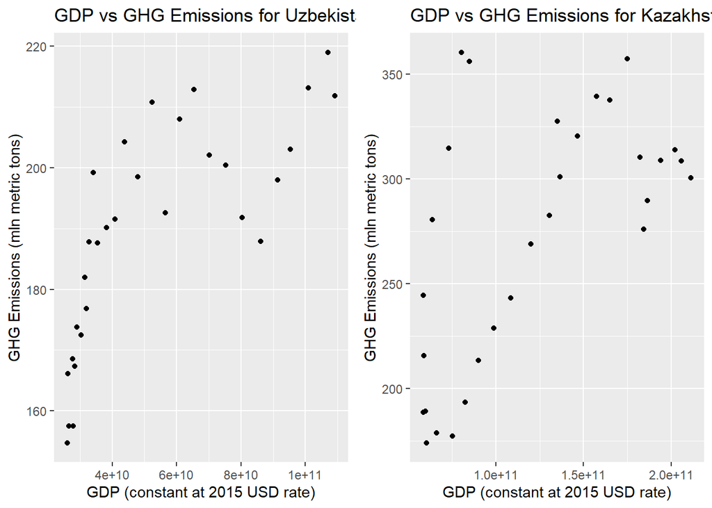

```r
grid.arrange(p1, p2, ncol=2)
```

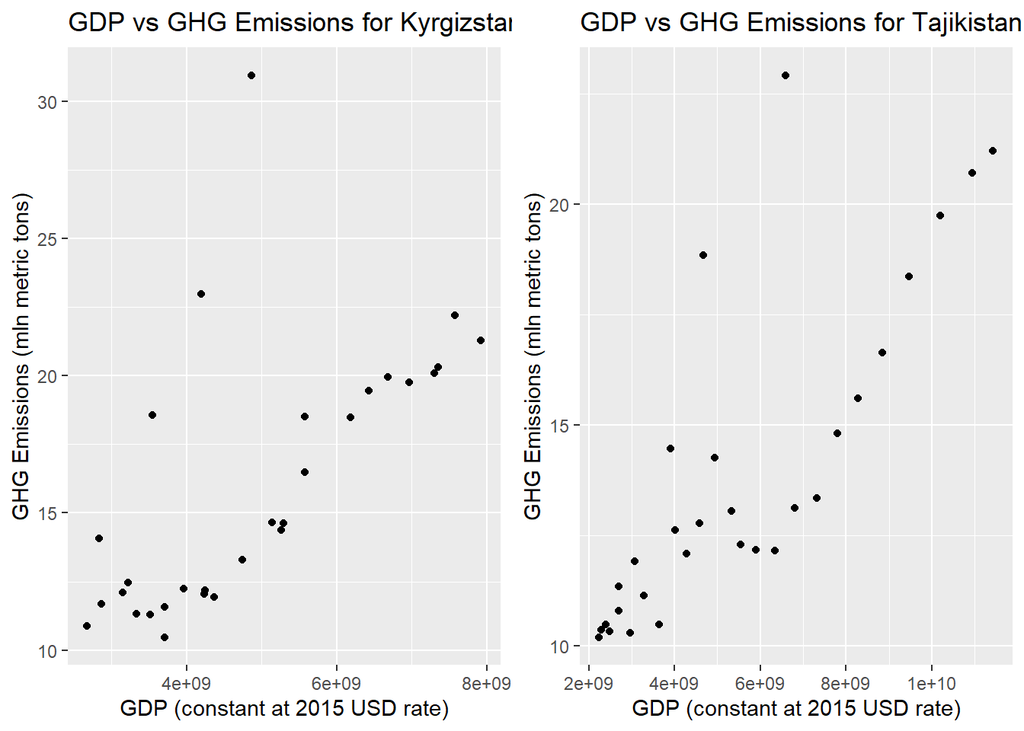

```r
grid.arrange(p3, p4, ncol=2)
```

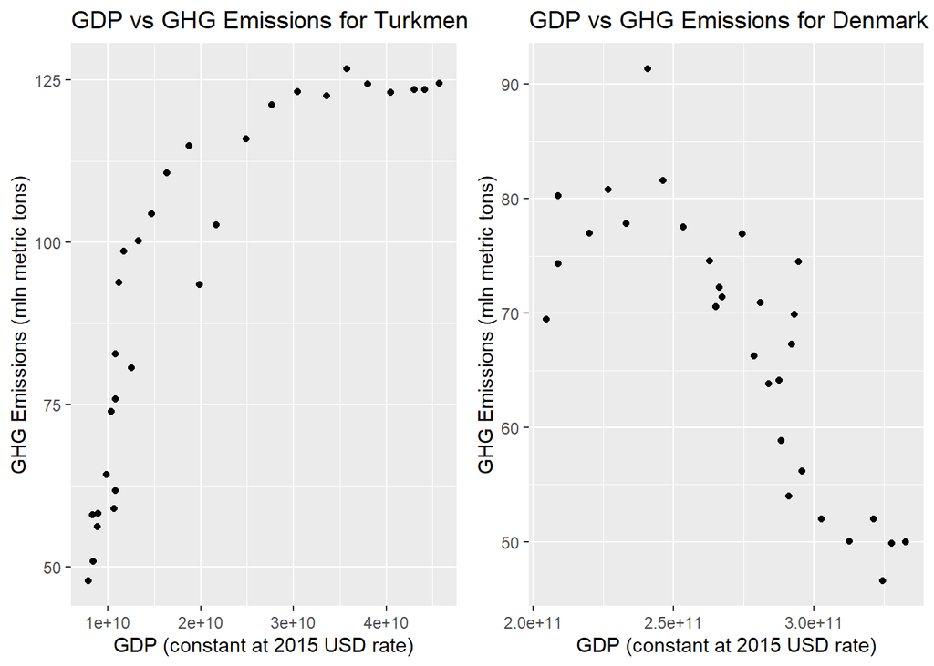

```r
grid.arrange(p5, p6, ncol=2)
```

## F

*Idiosyncratic error term for each country in each year:*

```
##      Denmark-1991      Denmark-1992      Denmark-1993      Denmark-1994
##      -0.273490315      -0.100017081      -0.186553066      -0.161793384
##      Denmark-1995      Denmark-1996      Denmark-1997      Denmark-1998
##      -0.101323043      -0.181920692       0.029640219      -0.065740742
##      Denmark-1999      Denmark-2000      Denmark-2001      Denmark-2002
##      -0.085182220      -0.074035977      -0.129789771      -0.089151388
##      Denmark-2003      Denmark-2004      Denmark-2005      Denmark-2006
##      -0.103898053       0.021596763      -0.013734779      -0.086025107
##      Denmark-2007      Denmark-2008      Denmark-2009      Denmark-2010
##       0.069284352       0.027037011      -0.027853941      -0.039653270
##      Denmark-2011      Denmark-2012      Denmark-2013      Denmark-2014
##       0.041236479       0.018846452      -0.062408476       0.054488213
##      Denmark-2015      Denmark-2016      Denmark-2017      Denmark-2018
##       0.030516876      -0.004422039       0.100895371       0.066639407
##      Denmark-2019      Denmark-2020   Kazakhstan-1991   Kazakhstan-1992
##       0.135649283       0.097854938       0.071383683       0.026493210
##   Kazakhstan-1993   Kazakhstan-1994   Kazakhstan-1995   Kazakhstan-1996
##       0.145118698       0.201925063       0.184139028       0.176430505
##   Kazakhstan-1997   Kazakhstan-1998   Kazakhstan-1999   Kazakhstan-2000
##       0.143337146       0.146937925       0.123402433       0.141144522
##   Kazakhstan-2001   Kazakhstan-2002   Kazakhstan-2003   Kazakhstan-2004
##       0.120322572       0.101949492       0.114085652       0.024137949
##   Kazakhstan-2005   Kazakhstan-2006   Kazakhstan-2007   Kazakhstan-2008
##       0.069397828      -0.014349229      -0.077511259      -0.011028392
##   Kazakhstan-2009   Kazakhstan-2010   Kazakhstan-2011   Kazakhstan-2012
##       0.016356119      -0.023990360      -0.113657538      -0.062913861
##   Kazakhstan-2013   Kazakhstan-2014   Kazakhstan-2015   Kazakhstan-2016
##      -0.143102370       0.004827358       0.073200436      -0.031987077
##   Kazakhstan-2017   Kazakhstan-2018   Kazakhstan-2019   Kazakhstan-2020
##       0.014431802      -0.126128313      -0.146650237      -0.002945636
##   Kyrgizstan-1991   Kyrgizstan-1992   Kyrgizstan-1993   Kyrgizstan-1994
##       0.264741270       0.106103246       0.014651899      -0.010036358
##   Kyrgizstan-1995   Kyrgizstan-1996   Kyrgizstan-1997   Kyrgizstan-1998
##      -0.106150597      -0.151243137      -0.151419614      -0.191711417
##   Kyrgizstan-1999   Kyrgizstan-2000   Kyrgizstan-2001   Kyrgizstan-2002
##      -0.136867288      -0.142935365      -0.218010354      -0.248534390
##   Kyrgizstan-2003   Kyrgizstan-2004   Kyrgizstan-2005   Kyrgizstan-2006
##      -0.178153541      -0.246691052      -0.254750864      -0.275926782
##   Kyrgizstan-2007   Kyrgizstan-2008   Kyrgizstan-2009   Kyrgizstan-2010
##      -0.255120207      -0.223753499      -0.185308362      -0.185096908
```

[output cut: 35 more lines]

```
##      -0.002663116      -0.006655947       0.019942470       0.052141663
##   Uzbekistan-1993   Uzbekistan-1994   Uzbekistan-1995   Uzbekistan-1996
##       0.038267770       0.048541305       0.099877185       0.091298362
##   Uzbekistan-1997   Uzbekistan-1998   Uzbekistan-1999   Uzbekistan-2000
##       0.059923907       0.113103722       0.066319177       0.074157512
##   Uzbekistan-2001   Uzbekistan-2002   Uzbekistan-2003   Uzbekistan-2004
##       0.086581317       0.108867332       0.071686600       0.069299577
##   Uzbekistan-2005   Uzbekistan-2006   Uzbekistan-2007   Uzbekistan-2008
##       0.110927315       0.118487546       0.083052695       0.095989760
##   Uzbekistan-2009   Uzbekistan-2010   Uzbekistan-2011   Uzbekistan-2012
##       0.061898138       0.058849976       0.032805736       0.072536363
##   Uzbekistan-2013   Uzbekistan-2014   Uzbekistan-2015   Uzbekistan-2016
##       0.053473328       0.043984795       0.040417453       0.043801365
##   Uzbekistan-2017   Uzbekistan-2018   Uzbekistan-2019   Uzbekistan-2020
##       0.029381932      -0.083175934      -0.048685721      -0.062917961
```

## G

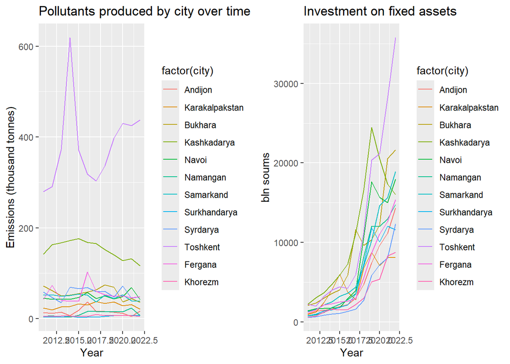

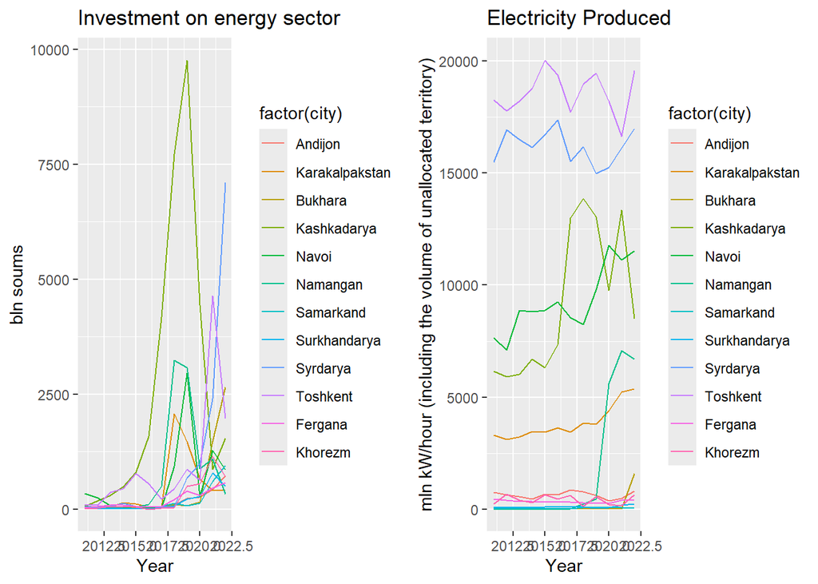

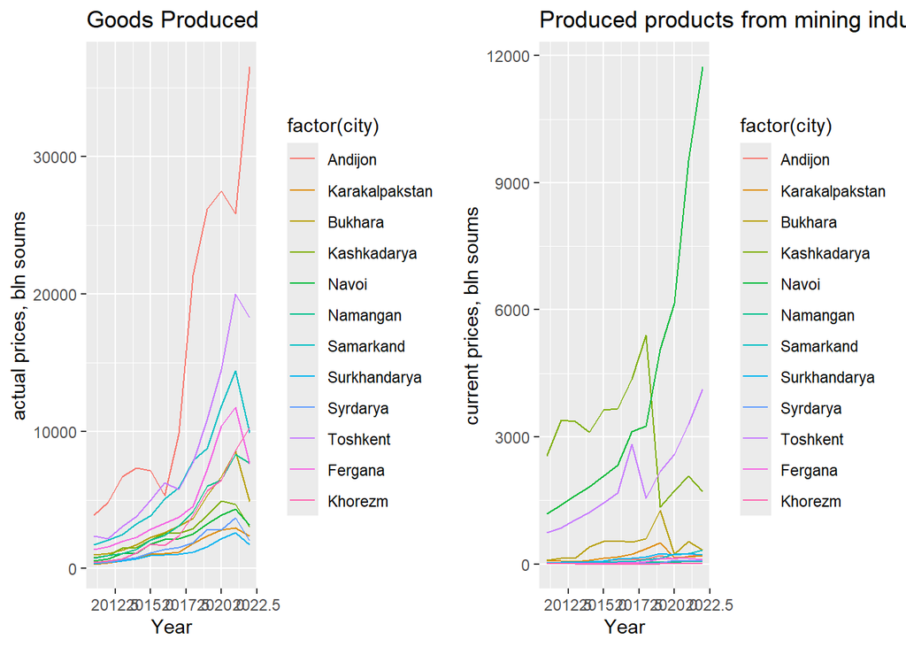

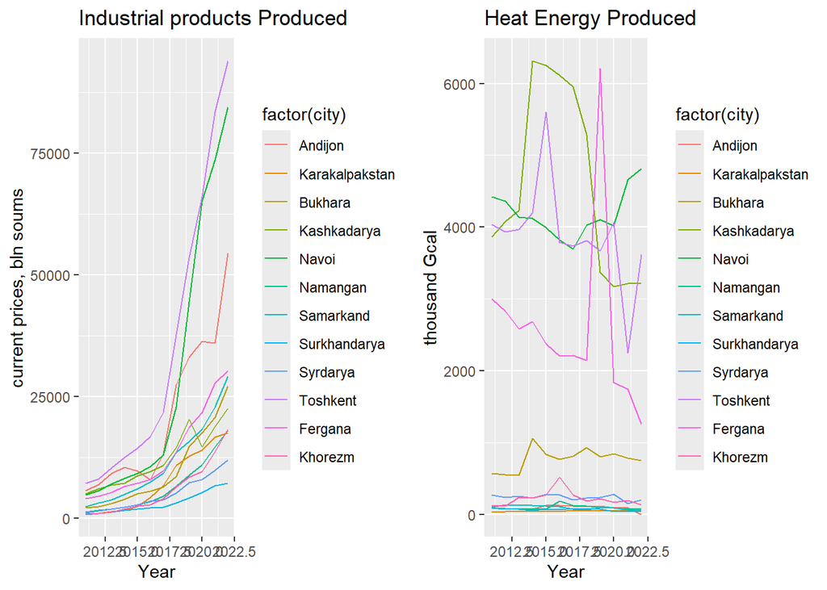

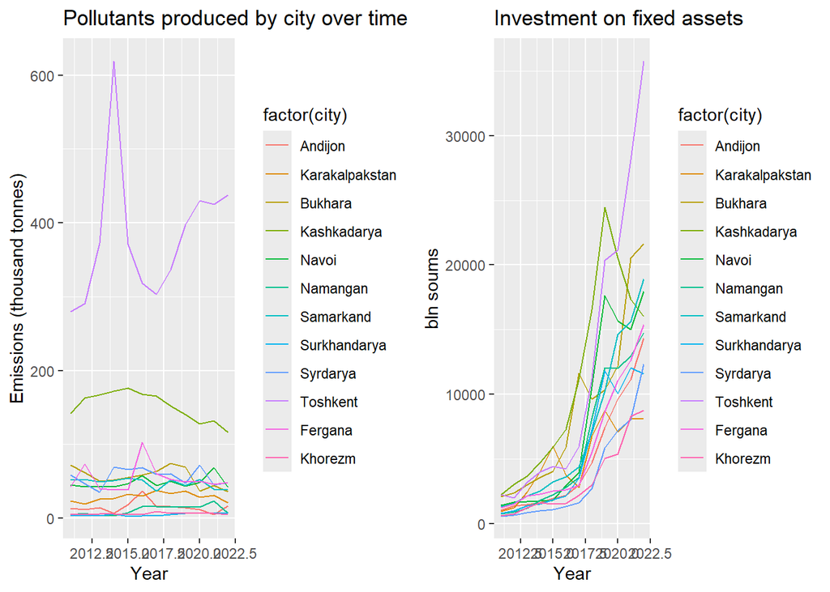

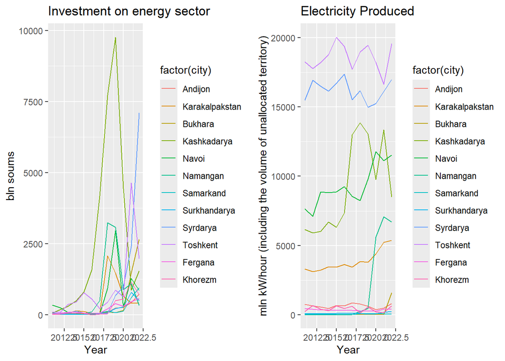

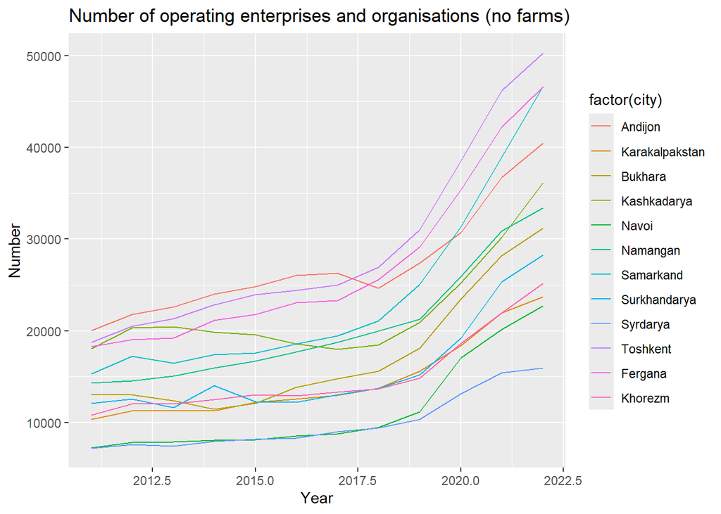

## H

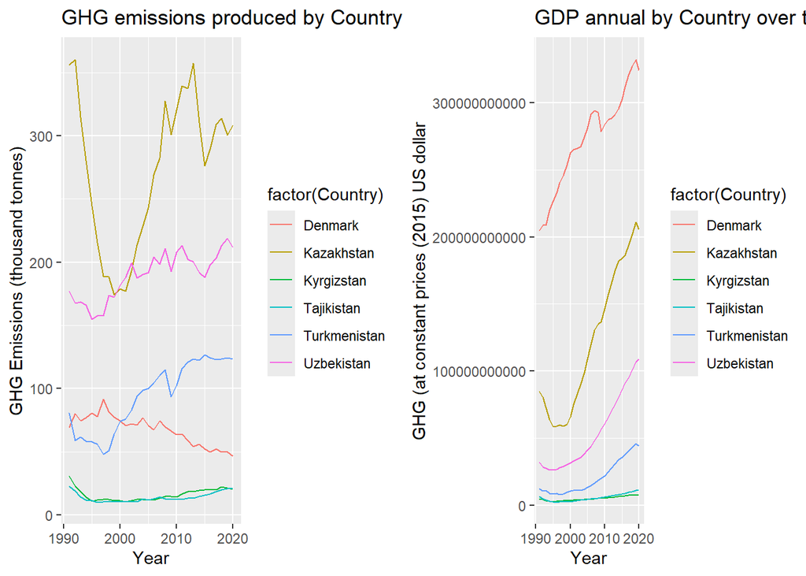

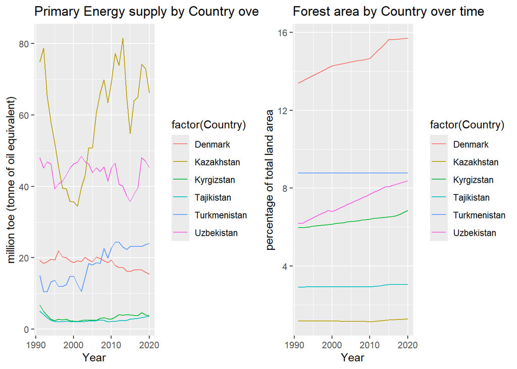

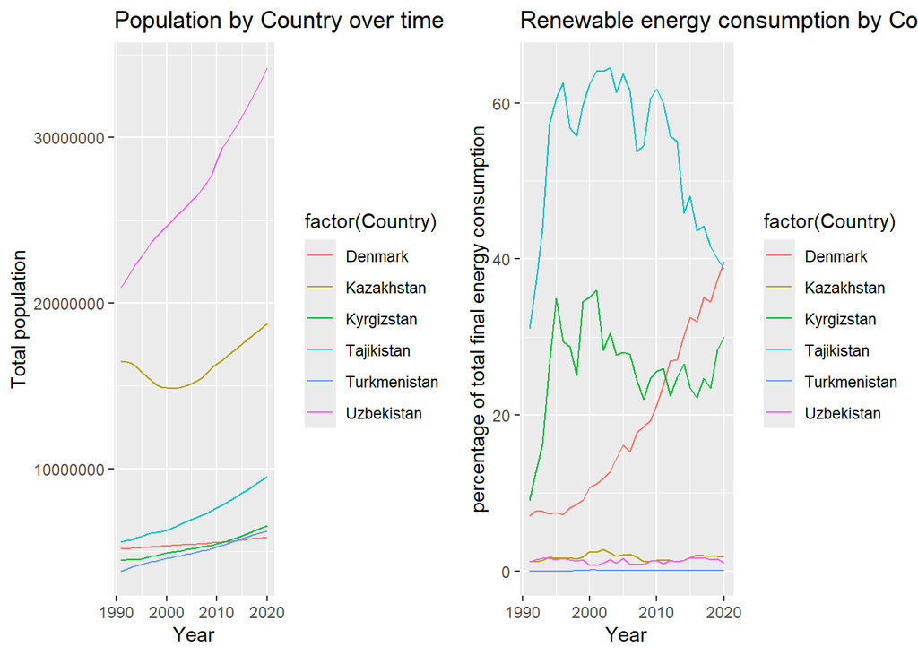